# Taller 1 · Comparador de precios de cuidado bucal

Minería de Datos (2016325) · Universidad Nacional de Colombia

Autor/a

David Márquez

Fecha de publicación

9 de octubre de 2026

```python
# Parámetros (quarto render taller_1.qmd -P EJECUTAR_SCRAPING:true)
EJECUTAR_SCRAPING = False       # True: nueva ejecución en línea antes del análisis
VERIFICAR_SIN_CONEXION = True   # reprocesa raw/ en una base temporal y compara con la base entregada
EJECUCION_REFERENCIA = None     # None: la más reciente con cobertura completa (regla R9)
```

**Ver código**

```python
import json, sqlite3, sys, tempfile, textwrap, platform
from pathlib import Path

import numpy as np
import pandas as pd
import matplotlib
import matplotlib.pyplot as plt
from matplotlib.ticker import FuncFormatter
from IPython.display import display, HTML

import scraper      # módulo de extracción (una función por comercio)
import limpieza     # reglas de normalización y correspondencia

DB = scraper.DB_PATH
plt.rcParams.update({"figure.dpi": 110, "axes.spines.top": False, "axes.spines.right": False,
                     "axes.titleweight": "bold", "axes.titlesize": 12})

def cop(x):
    return "—" if x is None or pd.isna(x) else "$ " + f"{x:,.0f}".replace(",", ".")

def pct(x):
    return "—" if x is None or pd.isna(x) else f"{x:.1f} %".replace(".", ",")

def num(x, d=2):
    return "—" if x is None or pd.isna(x) else f"{x:,.{d}f}".replace(",", "X").replace(".", ",").replace("X", ".")

FMT_COP = FuncFormatter(lambda x, _: cop(x))

def consulta(sql, **params):
    return pd.read_sql_query(sql, con, params=params)

def tabla(df, cop_cols=(), pct_cols=(), dec_cols=(), max_filas=60):
    t = df.copy()
    for c in cop_cols: t[c] = t[c].map(cop)
    for c in pct_cols: t[c] = t[c].map(pct)
    for c in dec_cols: t[c] = t[c].map(num)
    t = t.astype(object).where(t.notna(), "—")
    nota = ""
    if len(t) > max_filas:
        nota = f"<p><em>Se muestran {max_filas} de {len(t)} filas.</em></p>"
        t = t.head(max_filas)
    return HTML(t.to_html(index=False, na_rep="—", border=0, escape=True,
                          classes="table table-sm table-striped") + nota)

def ent(x):
    return "—" if x is None or pd.isna(x) else f"{int(x):,}".replace(",", ".")

def md(texto):
    print(textwrap.dedent(texto).strip() + "\n")
```

```python
if EJECUTAR_SCRAPING:
    display(scraper.ejecutar_recoleccion())          # en línea: una sola llamada

if not Path(DB).exists():
    raise FileNotFoundError("No existe comparador_precios.sqlite. Ejecute `python scraper.py` "
                            "o renderice con -P EJECUTAR_SCRAPING:true")

con = scraper.conectar(DB)
if EJECUCION_REFERENCIA:
    limpieza.marcar_comparables(con, EJECUCION_REFERENCIA); con.commit()

params = dict(con.execute("SELECT clave, valor FROM parametros").fetchall())
EJEC = params.get("ejecucion_referencia")
COM_REF = params.get("comercios_referencia", "").split(",")
N_COM = len(COM_REF)
NOMBRES = dict(con.execute("SELECT comercio_id, nombre FROM comercios").fetchall())
PALETA = ["#1b9e77", "#d95f02", "#7570b3", "#e7298a", "#66a61e", "#e6ab02"]
COLORES = {NOMBRES[c]: PALETA[i % len(PALETA)] for i, c in enumerate(sorted(NOMBRES))}
N_COMPARABLES = con.execute("SELECT COUNT(*) FROM productos WHERE comparable = 1").fetchone()[0]
print(f"Ejecución de referencia: {EJEC} · comercios: {', '.join(NOMBRES[c] for c in COM_REF)} · "
      f"presentaciones comparables: {N_COMPARABLES}")
```

```
Ejecución de referencia: E20261009T112120 · comercios: Éxito, Locatel, Olímpica · presentaciones comparables: 84
```

# 1 Introducción

Este trabajo construye un comparador de precios para la categoría **cuidado bucal** a partir de datos recolectados mediante *web scraping* en **3 comercios con venta en línea en Colombia**: **Éxito**, **Locatel**, **Olímpica**. El objetivo es identificar dónde resulta más económico comprar cada presentación y, cuando hay varios tamaños del mismo producto, cuál ofrece el menor precio por unidad de contenido (mL, g, m o unidad).

La base contiene **4 ejecuciones** de recolección (`E20261009T104100`, `E20261009T104416`, `E20261009T110227`, `E20261009T112120`). Las comparaciones se hacen con los precios de una misma ejecución, la de referencia (`E20261009T112120`), elegida con la regla R9 (sección 3).

**Delimitación de la categoría.** Se consideran de cuidado bucal las cremas dentales, cepillos dentales (manuales, eléctricos, interdentales y sus repuestos), enjuagues bucales, seda e hilo dental, productos de blanqueamiento, limpiadores linguales, productos para el aliento, cuidado de prótesis dental y los kits que combinan estos productos. Se excluyen artículos que algunos comercios ubican en la misma sección pero que no pertenecen a la categoría (chicles, caramelos, protectores labiales, productos para mascotas, entre otros). Esta delimitación sigue la registrada en la planilla «Categorías de Productos - Estudiantes».

| Subcategoría | Expresión regular (R3) |
| --- | --- |
| Kits y combos | \b(kit\|kits\|combo\|combos\|estuche\|set)\b |
| Cuidado de prótesis dental | \b(protesis\|dentadura\|dentaduras\|adhesivo\|adhesiva\|fijador\|corega\|fixodent\|polident\|retenedor\|retenedores)\b |
| Seda e hilo dental | \b(seda\|sedas\|hilo\|hilos\|cinta) dental(es)?\b\|\bfloss\|\bflosser\|\bportahilo\|\barcos? dental |
| Cepillo interdental | \b(interdental\|interdentales\|interproximal\|interproximales)\b |
| Repuesto de cepillo eléctrico | ^(repuesto\|repuestos\|cabezal\|cabezales\|refill)\b\|\b(repuesto\|repuestos\|cabezales\|refill) (de \|para )?cepillo |
| Cepillo dental eléctrico | \bcepillos?\b.*\b(electrico\|electricos\|bateria\|baterias\|recargable\|pilas\|sonico\|sonic)\b |
| Cepillo dental | \bcepillos?\b |
| Crema dental | \b(cremas?\|pastas?\|geles?\|gel) (de )?(dental\|dentales\|dientes)\b\|\bdentifrico\|\btoothpaste |
| Enjuague bucal | \b(enjuague\|enjuagues\|colutorio\|antiseptico bucal\|agua bucal\|mouthwash\|plax\|listerine)\b |
| Blanqueamiento dental | \b(blanqueador\|blanqueadora\|blanqueamiento\|tiras blanqueadoras\|lapiz blanqueador)\b |
| Aliento y spray bucal | \b(spray\|aliento\|refrescante bucal)\b |
| Limpiador lingual | \b(lingual\|raspador\|limpiador de lengua\|limpia lengua)\b |

| presentacion | subcategoria | marca | contenido_total | unidad | metodo | ean |
| --- | --- | --- | --- | --- | --- | --- |
| Vitis Blanqueado Past Tubx100Ml | Blanqueamiento dental | Vitis | 100,00 | ml | EAN | 08427426035355 |
| Colgate Cep Harry Potter +6 | Cepillo dental | Colgate | 2,00 | und | EAN | 07509546702469 |
| Colgate Encias Therapy — 2 x 10 g | Cepillo dental | Colgate | 2,00 | und | EAN | 07509546667744 |
| Colgate Kids Extra Suave — 2 und | Cepillo dental | Colgate | 2,00 | und | EAN | 07509546680859 |
| Colgate Medio — 5 und | Cepillo dental | Colgate | 5,00 | und | EAN | 07702010631795 |
| Colgate Ninos Smiles Extra Suave — 1 und | Cepillo dental | Colgate | 1,00 | und | EAN | 07591083011081 |
| Colgate Procuidado Suave — 4 und | Cepillo dental | Colgate | 4,00 | und | EAN | 07509546074313 |
| Colgate Sensitive Therapy — 1 und | Cepillo dental | Colgate | 1,00 | und | EAN | 07509546686912 |
| Colgate Slim Soft Suave — 2 und | Cepillo dental | Colgate | 2,00 | und | EAN | 07591083017793 |
| Colgate Suave — 2 und | Cepillo dental | Colgate | 2,00 | und | EAN | 07891024316207 |
| Colgate Triple Accion Blancura Medio — 2 x 50 g | Cepillo dental | Colgate | 2,00 | und | EAN | 07509546069982 |
| Colgate Twister Medio — 2 und | Cepillo dental | Colgate | 2,00 | und | EAN | 07702010130632 |
| Fluocardent Limpieza Max — 2 und [030888] | Cepillo dental | Fluocardent | 2,00 | und | EAN | 07702560030888 |
| Oral-B 5 Acciones Carbon Suave — 4 und | Cepillo dental | Oral-B | 4,00 | und | EAN | 07500435171069 |
| Oral-B 7 Beneficios — 2 x 64 g | Cepillo dental | Oral-B | 2,00 | und | EAN | 07501001100285 |
| Oral-B Iconic — 1 und | Cepillo dental | Oral-B | 1,00 | und | EAN | 07500435182218 |
| Oral-B Indicator Black — 2 x 40 g | Cepillo dental | Oral-B | 2,00 | und | EAN | 07500435210430 |
| Oral-B Indicator Extra Suave — 2 und | Cepillo dental | Oral-B | 2,00 | und | EAN | 07500435170987 |
| Oral-B Purification — 2 und | Cepillo dental | Oral-B | 2,00 | und | EAN | 07500435143790 |
| Pro Doble Accion — 2 und | Cepillo dental | Pro | 2,00 | und | EAN | 07501086454181 |
| Oral-B Electrico Io Series 2 — 1 und | Cepillo dental eléctrico | Oral-B | 1,00 | und | EAN | 07500435249805 |
| Oral-B Electrico Spiderman — 1 und | Cepillo dental eléctrico | Oral-B | 1,00 | und | EAN | 04210201409052 |
| Colgate Blanqueadora Luminous Brilliant — 75 ml | Crema dental | Colgate | 75,00 | ml | EAN | 07509546054650 |
| Colgate Blanqueadora Luminous White Carbon — 75 ml | Crema dental | Colgate | 75,00 | ml | EAN | 07509546651019 |
| Colgate Blanqueadora Luminous White Glow — 70 g | Crema dental | Colgate | 70,00 | g | EAN | 07509546676258 |
| Colgate Carbon Activado — 75 ml | Crema dental | Colgate | 75,00 | ml | EAN | 07509546683799 |
| Colgate Kids Minions — 45 ml | Crema dental | Colgate | 60,00 | g | EAN | 07509546660561 |
| Colgate Luminous White Brilliant — 125 ml | Crema dental | Colgate | 125,00 | ml | EAN | 07509546053875 |
| Colgate Luminous White Color Correct — 87 g | Crema dental | Colgate | 66,00 | ml | EAN | 07509546700403 |
| Colgate Max White — 131 ml | Crema dental | Colgate | 131,00 | ml | EAN | 07891024123362 |

[output cut: 54 more lines]

La tabla anterior lista las **84 presentaciones comparables**: aparecen con precio disponible en los 3 comercios dentro de la misma ejecución y provienen de la extracción completa de la categoría, no de búsquedas manuales. Se distribuyen en 9 subcategorías y 10 marcas.

# 2 Fuentes y *scraping*

## 2.1 Comercios y estrategia de extracción

Los tres comercios usan la plataforma VTEX. Sus páginas de categoría se alimentan de servicios JSON públicos del propio sitio; el módulo `scraper.py` los consulta con peticiones HTTP directas (librería `requests`), sin automatizar un navegador:

1. **Árbol de categorías** — `GET /api/catalog_system/pub/category/tree/4`. Se recorre el árbol y se eligen las secciones cuyo nombre coincide con `(cuidado|salud|higiene) (oral|bucal|dental)` (sin bajar dentro de una sección ya elegida y excluyendo rutas de mascotas).
2. **Productos de cada sección** — `GET /api/catalog_system/pub/products/search?fq=C:/<ids>/&_from=&_to=&O=OrderByNameASC`, de 50 en 50 (máximo que admite la API). El encabezado `resources: 0-49/N` informa el total *N* que reporta el sitio y permite saber cuándo termina la paginación. La API no pagina más allá de 2 500 resultados; ninguna sección llega a ese límite, y si lo superara la ejecución quedaría registrada como parcial.
3. **Copias crudas** — cada respuesta se guarda sin modificar, comprimida, en `raw/<comercio>/<fecha>/<ejecución>/` con un `manifest.json` (URL, parámetros, fecha y hora, código HTTP). Los datos **siempre se procesan desde estas copias**, tanto en línea como sin conexión, por lo que ambos modos producen el mismo resultado (sección 7.3). Cada ejecución guarda también el `robots.txt` de cada sitio.

Los servicios se identificaron con las herramientas de desarrollador del navegador (pestaña *Red*) al abrir la página de la categoría en cada sitio: las peticiones a `/api/catalog_system/...` devuelven el JSON con nombre, marca, EAN, precio, precio de lista y disponibilidad que la página muestra.

| comercio | tipo | url_base | plataforma |
| --- | --- | --- | --- |
| Locatel | Droguería / salud | https://www.locatelcolombia.com | VTEX |
| Olímpica | Supermercado y droguería | https://www.olimpica.com | VTEX |
| Éxito | Gran superficie | https://www.exito.com | VTEX |

```python
# Una función por comercio, mismas columnas de salida (scraper.COLUMNAS)
[f.__name__ for f in scraper.FUNCIONES.values()], len(scraper.COLUMNAS)
```

```
(['extraer_exito', 'extraer_olimpica', 'extraer_locatel'], 24)
```

## 2.2 Secciones equivalentes a la categoría y productos excluidos

| comercio | seccion | filtro | api | url | total_reportado | n_obtenidos |
| --- | --- | --- | --- | --- | --- | --- |
| Locatel | Cuidado personal > Cuidado oral | /1/10/ | catalogo | https://www.locatelcolombia.com/cuidado-personal/cuidado-oral | 369 | 369 |
| Olímpica | Supermercado > Cuidado Personal y Belleza > Cuidado Oral | /900000000/900110000/900110300/ | catalogo | https://www.olimpica.com/supermercado/cuidado-personal-y-belleza/cuidado-oral | 258 | 258 |
| Olímpica | Medicamentos > Cuidado De La Salud > Salud Oral | /901000000/901010000/901011100/ | catalogo | https://www.olimpica.com/medicamentos/cuidado-de-la-salud/salud-oral | 16 | 16 |
| Éxito | Cuidado personal > Cuidado oral | /34185083/34185114/ | catalogo | https://tienda.exito.com/cuidado-personal/cuidado-oral | 1730 | 1730 |

| comercio | motivo | anuncios | ejemplos |
| --- | --- | --- | --- |
| Éxito | R4: no pertenece a cuidado bucal (chicle) | 4 | Crema dental PROQUIDENT kids con sabor a chicle (75 ml) \| Gel dental infantil GUM Avengers sabor a chicle (75 gr) \| Seda dental flossers PROQUIDENT kids [...] |
| Locatel | R4: no pertenece a cuidado bucal (chicle) | 3 | Crema Dental Fitokids Chicle X 75Gr \| Crema Denture Kids 1000 Sabor Chicle X 50G \| Gel Dental Gum Paw Patrol 3 + Chicle X 75ml |
| Olímpica | R4: no pertenece a cuidado bucal (chicle) | 1 | Crema Dental Fitokids Chicle Para Niños 75 G |
| Éxito | R4: no pertenece a cuidado bucal (gatos) | 1 | Aspiradora Eléctrica De Pelos Para Gatos Y Perros Con Cepillo |
| Éxito | R4: no pertenece a cuidado bucal (mascotas) | 1 | Dedo Cepillo Dientes Y Encias Suave Bebe Infantil Mascotas Silicona Transparente X 3 Ref. Dl 6126 |
| Éxito | R4: no pertenece a cuidado bucal (shampoo) | 1 | Set De Baño Paw Patrol Shampoo Jabon Y Esponja Patrulla |

La primera tabla documenta qué secciones de cada sitio se consideraron equivalentes a la categoría (nombre, ruta de identificadores usada como filtro y URL de la página). La segunda resume los **11 anuncios excluidos** por no pertenecer a cuidado bucal según la delimitación (regla R4 o exclusión manual); quedan en la base con `incluido = 0` para que la exclusión sea verificable.

## 2.3 Completitud de la recolección

| ejecucion_id | comercio | inicio | estado | total_reportado_sitio | productos_obtenidos | skus_obtenidos | mensaje |
| --- | --- | --- | --- | --- | --- | --- | --- |
| E20261009T104100 | Locatel | 2026-10-09T10:43:12-05:00 | completa | 369 | 369 | 369 | — |
| E20261009T104100 | Olímpica | 2026-10-09T10:42:55-05:00 | completa | 274 | 274 | 274 | — |
| E20261009T104100 | Éxito | 2026-10-09T10:41:02-05:00 | completa | 1730 | 1730 | 1740 | — |
| E20261009T104416 | Locatel | 2026-10-09T10:45:41-05:00 | completa | 369 | 369 | 369 | — |
| E20261009T104416 | Olímpica | 2026-10-09T10:45:29-05:00 | completa | 274 | 274 | 274 | — |
| E20261009T104416 | Éxito | 2026-10-09T10:44:18-05:00 | completa | 1730 | 1730 | 1740 | — |
| E20261009T110227 | Locatel | 2026-10-09T11:04:53-05:00 | completa | 369 | 369 | 369 | — |
| E20261009T110227 | Olímpica | 2026-10-09T11:04:32-05:00 | completa | 274 | 274 | 274 | — |
| E20261009T110227 | Éxito | 2026-10-09T11:02:29-05:00 | completa | 1730 | 1730 | 1740 | — |
| E20261009T112120 | Locatel | 2026-10-09T11:23:33-05:00 | completa | 369 | 369 | 369 | — |
| E20261009T112120 | Olímpica | 2026-10-09T11:23:13-05:00 | completa | 274 | 274 | 274 | — |
| E20261009T112120 | Éxito | 2026-10-09T11:21:23-05:00 | completa | 1730 | 1730 | 1740 | — |

En la ejecución de referencia, 3 de 3 comercios quedaron con estado **completa**: el número de productos obtenidos coincide con el total que reporta el propio sitio en el encabezado `resources` de su API (es la cifra con la que el sitio pagina la categoría). El número de SKU puede superar al de productos porque un producto VTEX puede tener varias variantes (por ejemplo, colores de un cepillo). Como verificación adicional, el archivo opcional `conteo_sitio_web.csv` registra el número de resultados que muestra la página web de la categoría el día de la captura.

## 2.4 Condiciones de uso y buenas prácticas

| comercio | ruta | permitido | crawl_delay | fecha_revision |
| --- | --- | --- | --- | --- |
| Éxito | /api/catalog_system/pub/category/tree/4 | True | — | 2026-10-09 |
| Éxito | /api/catalog_system/pub/products/search | True | — | 2026-10-09 |
| Locatel | /api/catalog_system/pub/category/tree/4 | True | — | 2026-10-09 |
| Locatel | /api/catalog_system/pub/products/search | True | — | 2026-10-09 |
| Olímpica | /api/catalog_system/pub/category/tree/4 | True | — | 2026-10-09 |
| Olímpica | /api/catalog_system/pub/products/search | True | — | 2026-10-09 |

Buenas prácticas aplicadas: pausa de 1 s entre peticiones, reintentos con espera exponencial ante respuestas 429/5xx, un *User-Agent* que identifica el uso académico, solo servicios públicos (sin inicio de sesión, sin datos personales ni carrito), y consulta únicamente de la categoría asignada. La tabla anterior evalúa con `urllib.robotparser` si las rutas usadas están permitidas en el `robots.txt` de cada sitio (la copia queda en `raw/<comercio>/robots/`); el analizador estándar no interpreta comodines (`*`), por lo que el resultado se revisó también leyendo el archivo.

# 3 Preparación de los datos

## 3.1 Reglas de limpieza y correspondencia

El texto original de cada anuncio (nombre, nombre del SKU, marca, categoría, descripción y ficha técnica) se conserva sin cambios en la tabla `anuncios`. Las versiones estandarizadas se guardan en campos propios (`*_std`, `contenido_*`, `familia`, `producto_id`) mediante `limpieza.py`:

| Regla | Descripción |
| --- | --- |
| R1 | Texto en minúsculas, sin tildes ni signos; coma decimal → punto. |
| R2 | Marca: primero una marca conocida en el nombre; si no, el campo marca del comercio. |
| R3 | Subcategoría por expresiones regulares (tabla de la introducción) sobre nombre + ruta de categoría. |
| R4 | Exclusión de anuncios que no son cuidado bucal (chicles, labiales, mascotas…). |
| R5 | Contenido y unidades: `75 ml`, `3 x 75 ml`, `100 ml caja x 3 und`, `x2`, `lleve 3 pague 2`; conversión a mL, g o m (1 L = 1000 mL, 1 kg = 1000 g, 1 g = 1000 mg); contenido total = contenido × unidades… |
| R6 | Concentración de flúor (ppm) o de principio activo (%) cuando aparece. |
| R7 | Familia: nombre sin tamaño, empaque ni marca (agrupa tamaños del mismo producto). |
| R8 | Correspondencia: manual (`correspondencias_manuales.csv`) → EAN/GTIN con dígito de control válido (separado por unidades) → clave normalizada. |
| R9 | Comparable: presentación con precio disponible en todos los comercios de la ejecución de referencia. |

Los precios se convierten a número en COP; un precio ausente o igual a cero en el sitio queda como `NULL` (nunca 0). El precio extraído es el del vendedor principal del SKU; se marca como promoción cuando el precio de lista es mayor, y los textos de promociones condicionadas (p. ej. «2x1») se guardan aparte porque no modifican el precio extraído.

## 3.2 Ejemplos de estandarización

| comercio | nombre_original | marca_original | marca_std | subcategoria_std | contenido_unitario | n_unidades | contenido_total | unidad | concentracion | alerta_limpieza |
| --- | --- | --- | --- | --- | --- | --- | --- | --- | --- | --- |
| Éxito | Cepillo Dental Con Estuche X 4 | CORONA | Corona | Kits y combos | — | 4 | — | — | — | — |
| Éxito | Cepillo ORALPLUS X3 Complete Textura Media (3 und) | ORAL-PLUS | Oral Plus | Cepillo dental | 1,00 | 3 | 3,00 | und | — | — |
| Éxito | Cepillo de dientes COLGATE kids, extra suave (2 und) | COLGATE | Colgate | Cepillo dental | 1,00 | 2 | 2,00 | und | — | — |
| Éxito | Cepillo de dientes COLGATE triple acción medio (3 und) | COLGATE | Colgate | Cepillo dental | 1,00 | 3 | 3,00 | und | — | — |
| Éxito | Cepillo de dientes GUM deep clean suave (2 und) | GUM | GUM | Cepillo dental | 1,00 | 2 | 2,00 | und | — | — |
| Éxito | Cepillo de dientes GUM para niños con limpiador de lengua (2 und) | GUM | GUM | Cepillo dental | 1,00 | 2 | 2,00 | und | — | — |
| Éxito | Cepillo de dientes ORALB 7 beneficios suave (2 und) | ORAL-B | Oral-B | Cepillo dental | 1,00 | 2 | 2,00 | und | — | — |
| Éxito | Cepillo de dientes ORALB radiant medio (2 und) | ORAL-B | Oral-B | Cepillo dental | 1,00 | 2 | 2,00 | und | — | — |
| Éxito | Crema dental COLGATE triple acción (375 ml) | COLGATE | Colgate | Crema dental | 375,00 | 3 | 1.125,00 | ml | — | — |
| Éxito | Crema dental FLUOCARDENT bipack triple acción max (150 ml) | FLUOCARDENT | Fluocardent | Crema dental | 150,00 | 2 | 300,00 | ml | — | — |
| Éxito | Crema dental FLUOCARDENT triple acción max (450 ml) | FLUOCARDENT | Fluocardent | Crema dental | 450,00 | 3 | 1.350,00 | ml | — | — |
| Éxito | Kit de ortodoncia ORALPLUS flex (8 und) | ORAL-PLUS | Oral Plus | Kits y combos | — | 8 | — | — | — | — |
| Éxito | Pack X2 Crema dental COLGATE blanqueadora luminous brilliant (300 ml) | COLGATE | Colgate | Crema dental | 300,00 | 2 | 600,00 | ml | — | — |
| Éxito | Repuesto para Cepillo Eléctrico ORALB precision clean (4 und) | ORAL-B | Oral-B | Repuesto de cepillo eléctrico | 1,00 | 4 | 4,00 | und | — | — |

## 3.3 Correspondencia de las presentaciones comparables

La validez de todas las comparaciones depende de esta tabla: para cada presentación se muestra el texto original con el que aparece en cada comercio y el método con que se emparejó.

| comercio | presentacion | metodo | Locatel | Olímpica | Éxito |
| --- | --- | --- | --- | --- | --- |
|  | Colgate Blanqueadora Luminous Brilliant — 75 ml | EAN | Crema Dental Blanqueadora Colgate Luminous White Brilliant X 75ml [SKU 3444] | Crema Dental Colgate Blanqueadora Luminous White Brilliant 75 Ml [SKU 796988] | Crema dental COLGATE blanqueadora luminous brilliant (75 ml) [SKU 387880] |
|  | Colgate Blanqueadora Luminous White Carbon — 75 ml | EAN | Crema Dental Blanqueadora Colgate Luminous White Carbon X 75ml [SKU 27108] | Crema Dental Colgate Blanqueadora Luminous White Carbon 75 Ml [SKU 2118374] | Crema dental COLGATE blanqueadora luminous carbón (75 ml) [SKU 1621322] |
|  | Colgate Blanqueadora Luminous White Glow — 70 g | EAN | Crema Dental Blanqueadora Colgate Luminous White Glow X 70g [SKU 48759] | Crema Dental Colgate Blanqueadora Luminous White Glow 70 G [SKU 2311909] | Crema dental COLGATE blanqueadora luminous glow (50 ml) [SKU 3401805] |
|  | Colgate Carbon Activado — 75 ml | EAN | Crema Dental Colgate Carbón Activado X 75ml [SKU 62376] | Crema Dental Colgate Total Carbón Prevención Activa 75 Ml [SKU 2300195] | Crema dental COLGATE total prevención activa carbón (75 ml) [SKU 3343486] |
|  | Colgate Cep Harry Potter +6 | EAN | Cepillo Dental Colgate Harry Potter Pack X 2 Und [SKU 63908] | CEP DENTAL COLGATE HARRY POTTER +6 2UN [SKU 2345794] | Cepillo De Dientes Harry Potter COLGATE Ultra suave (2 und) [SKU 3856682] |
|  | Colgate Encias Therapy — 2 x 10 g | EAN | Cepillo Dental Colgate Encias Therapy X 2 [SKU 55902] | Cepillo de Dientes Suave Colgate Encias Therapy X2 Unds [SKU 2204161] | Cepillo de dientes COLGATE encías therapy suave (2 und) [SKU 3036793] |
|  | Colgate Kids Extra Suave — 2 und | EAN | Cepillo Dental Colgate Kids Agnes 2-5 Años X 2Und [SKU 46200] | Cepillo de Dientes Niños Colgate Smiles Extra Suave X2 Unds [SKU 2263664] | Cepillo de dientes COLGATE kids, extra suave (2 und) [SKU 3224912] |
|  | Colgate Kids Minions — 45 ml | EAN | Crema Dental Colgate Kids Minions Agnes X 60G [SKU 43072] | Crema Dental Colgate Niños Agnes & Fluffy 60 G [SKU 2257815] | Crema dental COLGATE kids Minions (45 ml) [SKU 3201430] |
|  | Colgate Luminous White Brilliant — 125 ml | EAN | Crema Dental Colgate Luminous White Brilliant X 125ml [SKU 3443] | Crema Dental Colgate Blanqueadora Luminous White Brilliant 125 Ml [SKU 796989] | Crema dental COLGATE blanqueadora luminous brilliant (125 ml) [SKU 393892] |
|  | Colgate Luminous White Carbon — 575 ml | EAN | Oferta Enjuague Bucal Luminous White 500Ml + Crema Dental Luminous White Carbón Activado X 75G [SKU 42382] | Enjuague Bucal + Crema Dental Colgate Blanqueadora Luminous Carbon 75 Ml [SKU 2244925] | Enjuague bucal COLGATE + crema luminous white carbón (575 ml) [SKU 3145767] |
|  | Colgate Luminous White Color Correct — 87 g | EAN | Crema Dental Luminous White Color Correct X 87g [SKU 62163] | Crema Dental Blanqueadora Colgate Luminous White Color Correct 66 mL [SKU 2340489] | Crema dental COLGATE luminous white color correct (66 ml) [SKU 3763301] |
|  | Colgate Max White — 131 ml | EAN | Crema dental colgate max white X 131ml [SKU 58796] | Crema Dental Colgate Max White Complete Clean 180 G [SKU 1646686] | Crema dental COLGATE max white complete clean (131 ml) [SKU 1309252] |
|  | Colgate Maxima Proteccion Anticaries — 150 ml | EAN | Crema Dental Colgate Maxima Proteccion Anticaries X 150Ml [SKU 27453] | Crema Dental Colgate Menta 150 Ml [SKU 2122143] | Crema dental COLGATE máxima protección anticaries (150 ml) [SKU 6373] / Crema Dental Colgate Menta Anticaries 150 Ml [SKU 101359068] |
|  | Colgate Medio — 5 und | EAN | Cepillo Dental Colgate Limpieza Completa Medio X 5und [SKU 56030] | Cepillo de Dientes Medio Colgate 360° X5 Unds [SKU 1344740] | Cepillo de dientes COLGATE medio (5 und) [SKU 114143] |
|  | Colgate My First Sin Fluor — 40 ml | EAN | Crema Dental Colgate My First Sin Fluor X 40ml [SKU 3470] | Crema Dental Colgate Niños My First sin Flúor 50 G [SKU 996330] | Crema dental COLGATE kids my first sin fluor (40 ml) [SKU 405869] |
|  | Colgate Naturals Carbon — 25 m | EAN | Hilo Dental Colgate Natural Extracts X 25m [SKU 46080] | Seda Dental Colgate Carbón 25 Mts [SKU 2291928] | Seda dental COLGATE naturals carbón (25 mts) [SKU 3296597] |
|  | Colgate Ninos Smiles Extra Suave — 1 und | EAN | Cepillo Dental Colgate Smiles Extra Suave 0 - 2 Años X 1Und [SKU 3554] | Cepillo de Dientes Niños Colgate Smiles Extra Suave [SKU 1073667] | Cepillo de dientes COLGATE niños smiles extra suave (1 und) [SKU 354478] |
|  | Colgate Plax Kids Minions — 250 ml | EAN | Enjuague Bucal Colgate Plax Kids Minions X 250ml [SKU 23892] | Enjuague Bucal Colgate Plax Kids Minions 250 Ml [SKU 1290212] | Enjuague bucal COLGATE plax kids Minions (250 ml) [SKU 840098] |
|  | Colgate Plax Odor Control — 500 ml | EAN | Enjuague Bucal Colgate Plax Odor Control X 500ml [SKU 48762] | Enjuague Bucal Colgate Plax Odor Control 500 Ml [SKU 2299046] | Enjuague bucal COLGATE plax odor control (500 ml) [SKU 3295936] |
|  | Colgate Plax Soft Mint — 500 ml | EAN | Enjuague Bucal Colgate Plax Soft Mint X 500ml [SKU 27483] | Enjuague Bucal Colgate Plax Soft Mint 500 Ml [SKU 1102251] | Enjuague bucal COLGATE plax soft mint (500 ml) [SKU 1676204] |
|  | Colgate Procuidado Suave — 4 und | EAN | Cepillo Dental Colgate Pro Cuidado Suave X 4Und [SKU 23872] | Cepillo de Dientes Suave Colgate Pro Cuidado X4 Unds [SKU 1455963] | Cepillo de dientes COLGATE procuidado suave (4 und) [SKU 1229067] |
|  | Colgate Sensitive Blanqueadora — 73 ml | EAN | Crema Dental Colgate Sensitive Blanqueadora X 100g [SKU 7065] | Crema Dental Sensibilidad Colgate Sensitive Blanqueadora 73 Ml [SKU 1129006] | Crema dental COLGATE sensitive blanqueadora (73 ml) [SKU 483643] |
|  | Colgate Sensitive Pro Alivio — 60 g | EAN | Crema Dental Colgate Sensitive Pro Alivio X 40ml [SKU 60441] | Crema Dental Colgate Sensitive Pro Alivio Inmediato Original 60 G [SKU 2335614] | Crema dental COLGATE sensitive pro alivio (60 gr) [SKU 3711478] |
|  | Colgate Sensitive Proalivio — 140 g | EAN | Crema Dental Colgate Sensitive Proalivio X 140g [SKU 39927] | Crema Dental Colgate Sensitive Pro Alivio Inm Encías 140 G [SKU 2300194] | Crema dental COLGATE sensitive proalivio encías (93.3 ml) [SKU 3305038] |
|  | Colgate Sensitive Proalivio — 75 ml | EAN | Crema Dental Colgate Sensitive Pro Alivio X 110G [SKU 19976] | Crema Dental Colgate Sensitive Pro Alivio Inmediato Original 110 G [SKU 1245372] | Crema dental COLGATE sensitive proalivio (75 ml) [SKU 739983] |
|  | Colgate Sensitive Therapy — 1 und | EAN | Cepillo Dental Colgate Sensitive Ultra Suave X 1 Unidad [SKU 64383] | Cepillo de Dientes Colgate Sensitive Ultra Suave x 1 [SKU 2335339] | Cepillo Dental COLGATE Sensitive Therapy (1 und) [SKU 3798380] |
|  | Colgate Slim Soft Suave — 2 und | EAN | Cepillo de Dientes Colgate Slim Soft Suave X 2Und [SKU 3558] | Cepillo de Dientes Colgate Slim Soft Suave X2 Unds [SKU 933384] | Cepillo de dientes COLGATE slim soft suave (2 und) [SKU 129535] |
|  | Colgate Suave — 2 und | EAN | Cepillo de Dientes Suave Colgate 360 X 2Und [SKU 7092] | Cepillo de Dientes Suave Colgate 360° X2 Unds [SKU 1550400] | Cepillo de dientes COLGATE suave (2 und) [SKU 525538] |
|  | Colgate Total Encias Prevencion Activa — 500 ml | EAN | Enjuague Bucal Colgate Total Encías Prevención Activa 500ml [SKU 29602] | Enjuague Bucal Colgate Total Encías Prevención Activa 500 Ml [SKU 2197762] | Enjuague bucal COLGATE total prevención activa encías (500 ml) [SKU 3019241] |
|  | Colgate Total Original Mint — 150 ml | EAN | Crema Dental Total Original Mint Colgate X 150ml [SKU 3073] | Crema Dental Colgate Total Original Mint Prevención Activa 150ml [SKU 1566306] | Crema dental COLGATE original mint prevención activa (150 ml) [SKU 830954] |

[output cut: 54 more lines]

De las 84 presentaciones comparables, 84 se emparejaron por **EAN**. El EAN (código de barras) identifica una presentación específica —marca, variante, contenido y número de unidades—, por lo que es el criterio más exacto; además se verificó que el contenido y las unidades extraídos del nombre coincidieran dentro de cada grupo. 52 presentación(es) comparable(s) tienen alguna alerta de correspondencia (consulta 7). Los casos que las reglas no resuelven se corrigen en `correspondencias_manuales.csv` sin modificar el código.

# 4 Base de datos SQLite

## 4.1 Estructura

La base `comparador_precios.sqlite` (estructura definida en `esquema.sql`) separa entidades y hechos:

- `comercios` (1) → (n) `anuncios`: cada producto tal como aparece en un comercio, con su texto original, URL, SKU y EAN, más los campos estandarizados.
- `anuncios` (n) → (1) `productos`: identificador común (`producto_id`) de la misma presentación en todos los comercios, con el indicador `comparable`.
- `anuncios` (1) → (n) `observaciones`: precio, precio de lista, promoción, disponibilidad, URL de extracción, fecha y hora de consulta (ISO 8601, hora de Colombia) y ejecución.
- `ejecuciones`: una fila por corrida y comercio (inicio, registros, total reportado, estado); `secciones` documenta las secciones recorridas; `familias` y `parametros` son auxiliares.
- Restricciones: `UNIQUE(comercio_id, sku_comercio, fecha_hora_consulta)` y `UNIQUE(ejecucion_id, comercio_id, sku_comercio)` evitan insertar dos veces la misma observación; `CHECK` sobre el formato de fecha, precios positivos o `NULL` y estados válidos; llaves foráneas activas.

**Ver el esquema (DDL) almacenado en la base**

```python
for nombre, sql in con.execute("SELECT name, sql FROM sqlite_master WHERE type IN ('table','view') "
                               "AND name NOT LIKE 'sqlite_%' ORDER BY type, name"):
    print(sql, end=";\n\n")
```

```
CREATE TABLE anuncios (                   -- cada producto tal como aparece en un comercio
    anuncio_id INTEGER PRIMARY KEY AUTOINCREMENT, comercio_id TEXT NOT NULL REFERENCES comercios,
    sku_comercio TEXT NOT NULL, product_id_comercio TEXT, ean TEXT, referencia TEXT,
    -- texto publicado por el comercio, sin modificar
    nombre_original TEXT, nombre_item_original TEXT, marca_original TEXT, categoria_original TEXT,
    descripcion_original TEXT, ficha_tecnica_original TEXT, texto_original TEXT NOT NULL, url_producto TEXT,
    seccion_origen TEXT, primera_consulta TEXT NOT NULL, ultima_consulta TEXT NOT NULL,
    -- campos estandarizados por limpieza.py
    nombre_std TEXT, marca_std TEXT, subcategoria_std TEXT, contenido_unitario REAL, n_unidades INTEGER,
    contenido_total REAL, unidad TEXT, concentracion TEXT, familia TEXT, ean_valido TEXT,
    incluido INTEGER NOT NULL DEFAULT 1 CHECK (incluido IN (0, 1)), motivo_exclusion TEXT, alerta_limpieza TEXT,
    metodo_correspondencia TEXT, producto_id TEXT REFERENCES productos,
    comparable INTEGER NOT NULL DEFAULT 0 CHECK (comparable IN (0, 1)),
    UNIQUE (comercio_id, sku_comercio));

CREATE TABLE comercios (
    comercio_id TEXT PRIMARY KEY, nombre TEXT NOT NULL, tipo TEXT, url_base TEXT NOT NULL, plataforma TEXT);

CREATE TABLE ejecuciones (                -- una fila por corrida y comercio
    ejecucion_id TEXT NOT NULL, comercio_id TEXT NOT NULL REFERENCES comercios, inicio TEXT NOT NULL, fin TEXT,
    modo_carga TEXT NOT NULL CHECK (modo_carga IN ('en_linea', 'sin_conexion')),
    n_registros INTEGER NOT NULL DEFAULT 0, n_productos INTEGER NOT NULL DEFAULT 0, total_reportado_sitio INTEGER,
    estado TEXT NOT NULL CHECK (estado IN ('completa', 'parcial', 'fallida')), mensaje TEXT, carpeta_raw TEXT,
    PRIMARY KEY (ejecucion_id, comercio_id));

CREATE TABLE familias (familia TEXT PRIMARY KEY, nombre_familia TEXT);

CREATE TABLE observaciones (              -- precio de un anuncio en una ejecución
    observacion_id INTEGER PRIMARY KEY AUTOINCREMENT, ejecucion_id TEXT NOT NULL, comercio_id TEXT NOT NULL,
    anuncio_id INTEGER NOT NULL REFERENCES anuncios, sku_comercio TEXT NOT NULL,
    fecha_hora_consulta TEXT NOT NULL CHECK (fecha_hora_consulta GLOB
        '[0-9][0-9][0-9][0-9]-[0-9][0-9]-[0-9][0-9]T[0-9][0-9]:[0-9][0-9]:[0-9][0-9]-05:00'),
    precio REAL CHECK (precio > 0), precio_lista REAL CHECK (precio_lista > 0),
    es_promocion INTEGER NOT NULL CHECK (es_promocion IN (0, 1)), texto_promocion TEXT,
    disponible INTEGER CHECK (disponible IN (0, 1)), vendedor TEXT, url_fuente TEXT NOT NULL,
    comparable INTEGER NOT NULL DEFAULT 0 CHECK (comparable IN (0, 1)),
    FOREIGN KEY (ejecucion_id, comercio_id) REFERENCES ejecuciones (ejecucion_id, comercio_id),
    UNIQUE (comercio_id, sku_comercio, fecha_hora_consulta),   -- una observación no se inserta dos veces
    UNIQUE (ejecucion_id, comercio_id, sku_comercio));

CREATE TABLE parametros (clave TEXT PRIMARY KEY, valor TEXT);

CREATE TABLE productos (                  -- identificador común entre comercios (limpieza.py)
    producto_id TEXT PRIMARY KEY, nombre_estandar TEXT NOT NULL, marca TEXT, subcategoria TEXT, familia TEXT,
    contenido_unitario REAL, n_unidades INTEGER, contenido_total REAL, unidad TEXT, concentracion TEXT,
    ean TEXT, metodo_correspondencia TEXT, n_comercios INTEGER, alerta TEXT,
    comparable INTEGER NOT NULL DEFAULT 0 CHECK (comparable IN (0, 1)));

CREATE TABLE secciones (                  -- secciones del sitio equivalentes a la categoría
    ejecucion_id TEXT NOT NULL, comercio_id TEXT NOT NULL, seccion_id TEXT NOT NULL, nombre TEXT,
    ruta_nombres TEXT, filtro TEXT, url TEXT, api TEXT, total_reportado INTEGER, n_obtenidos INTEGER, error TEXT,
    PRIMARY KEY (ejecucion_id, comercio_id, seccion_id),
    FOREIGN KEY (ejecucion_id, comercio_id) REFERENCES ejecuciones (ejecucion_id, comercio_id));

CREATE VIEW v_observaciones AS
SELECT o.observacion_id, o.ejecucion_id, o.comercio_id, c.nombre AS comercio, a.anuncio_id, a.sku_comercio,
       a.ean_valido AS ean, a.producto_id, p.nombre_estandar, a.marca_std AS marca, a.subcategoria_std AS subcategoria,
       a.contenido_unitario, a.n_unidades, a.contenido_total, a.unidad, a.familia, o.precio, o.precio_lista,
       o.es_promocion, o.texto_promocion, o.disponible, o.fecha_hora_consulta, o.url_fuente, a.url_producto,
       o.comparable, a.incluido, a.nombre_original, a.texto_original
FROM observaciones o JOIN anuncios a ON a.anuncio_id = o.anuncio_id JOIN comercios c ON c.comercio_id = o.comercio_id
LEFT JOIN productos p ON p.producto_id = a.producto_id;
```

## 4.2 Validaciones

```python
validaciones = []
# 1. Unicidad: reinsertar una observación existente debe fallar
fila = con.execute("SELECT ejecucion_id, comercio_id, anuncio_id, sku_comercio, fecha_hora_consulta, "
                   "precio, es_promocion, url_fuente FROM observaciones LIMIT 1").fetchone()
try:
    con.execute("INSERT INTO observaciones (ejecucion_id, comercio_id, anuncio_id, sku_comercio, "
                "fecha_hora_consulta, precio, es_promocion, url_fuente) VALUES (?,?,?,?,?,?,?,?)", fila)
    validaciones.append(("Observación duplicada rechazada", False))
except sqlite3.IntegrityError:
    validaciones.append(("Observación duplicada rechazada", True))
con.rollback()
# 2. Fecha y hora obligatoria y en ISO 8601 con -05:00
validaciones.append(("Observaciones sin fecha/hora válida = 0", con.execute(
    "SELECT COUNT(*) FROM observaciones WHERE fecha_hora_consulta NOT GLOB "
    "'[0-9][0-9][0-9][0-9]-[0-9][0-9]-[0-9][0-9]T[0-9][0-9]:[0-9][0-9]:[0-9][0-9]-05:00'").fetchone()[0] == 0))
# 3. Ningún precio igual a cero
validaciones.append(("Precios iguales a 0 = 0", con.execute(
    "SELECT COUNT(*) FROM observaciones WHERE precio = 0").fetchone()[0] == 0))
# 4. Integridad referencial
validaciones.append(("PRAGMA foreign_key_check sin errores", len(con.execute("PRAGMA foreign_key_check").fetchall()) == 0))
# 5. Toda observación pertenece a una ejecución registrada
validaciones.append(("Observaciones con ejecución registrada", con.execute(
    "SELECT COUNT(*) FROM observaciones o LEFT JOIN ejecuciones e USING (ejecucion_id, comercio_id) "
    "WHERE e.ejecucion_id IS NULL").fetchone()[0] == 0))
pd.DataFrame(validaciones, columns=["validación", "cumple"])
```

|  | validación | cumple |
| --- | --- | --- |
| 0 | Observación duplicada rechazada | True |
| 1 | Observaciones sin fecha/hora válida = 0 | True |
| 2 | Precios iguales a 0 = 0 | True |
| 3 | PRAGMA foreign_key_check sin errores | True |
| 4 | Observaciones con ejecución registrada | True |

# 5 Consultas SQL

Todas las comparaciones de precios usan la ejecución de referencia (`:ejec`) y, cuando un comercio tiene más de un anuncio de la misma presentación, el menor precio disponible.

```python
# Precios de las presentaciones comparables en la ejecución de referencia (base de varias consultas)
CTE_PRECIOS = """
WITH precios AS (
    SELECT producto_id, nombre_estandar, comercio, MIN(precio) AS precio
    FROM v_observaciones
    WHERE ejecucion_id = :ejec AND comparable = 1 AND precio IS NOT NULL AND disponible = 1
    GROUP BY producto_id, comercio
)"""
```

## 5.1 ¿Cuántos comercios, presentaciones y observaciones contiene la base?

```python
q1a = consulta("""
SELECT (SELECT COUNT(DISTINCT comercio_id) FROM observaciones)               AS comercios,
       (SELECT COUNT(DISTINCT ejecucion_id) FROM ejecuciones)                AS ejecuciones,
       (SELECT COUNT(*) FROM anuncios WHERE incluido = 1)                    AS anuncios_categoria,
       (SELECT COUNT(DISTINCT producto_id) FROM anuncios WHERE incluido = 1) AS productos_presentaciones,
       (SELECT COUNT(*) FROM productos WHERE comparable = 1)                 AS presentaciones_comparables,
       (SELECT COUNT(*) FROM observaciones)                                  AS observaciones,
       (SELECT COUNT(*) FROM observaciones WHERE comparable = 1)             AS observaciones_comparables
""")
q1b = consulta("""
SELECT c.nombre AS comercio,
       COUNT(DISTINCT a.anuncio_id)                                         AS anuncios,
       COUNT(DISTINCT a.producto_id)                                        AS presentaciones,
       COUNT(DISTINCT CASE WHEN a.comparable = 1 THEN a.producto_id END)    AS comparables,
       COUNT(o.observacion_id)                                              AS observaciones
FROM anuncios a
JOIN comercios c ON c.comercio_id = a.comercio_id
LEFT JOIN observaciones o ON o.anuncio_id = a.anuncio_id
WHERE a.incluido = 1
GROUP BY c.nombre
ORDER BY anuncios DESC
""")
display(tabla(q1a)); display(tabla(q1b))
```

| comercios | ejecuciones | anuncios_categoria | productos_presentaciones | presentaciones_comparables | observaciones | observaciones_comparables |
| --- | --- | --- | --- | --- | --- | --- |
| 3 | 4 | 2372 | 1989 | 84 | 9532 | 1016 |

| comercio | anuncios | presentaciones | comparables | observaciones |
| --- | --- | --- | --- | --- |
| Éxito | 1733 | 1699 | 84 | 6932 |
| Locatel | 366 | 366 | 84 | 1464 |
| Olímpica | 273 | 273 | 84 | 1092 |

**Interpretación.** La base reúne 3 comercios, 4 ejecuciones y 9.532 observaciones de precio sobre 1.989 presentaciones distintas de cuidado bucal (2.372 anuncios). Éxito aporta la oferta más amplia (1.733 anuncios) y Olímpica la más reducida (273). Solo 84 presentaciones están en los 3 comercios: la mayor parte de la oferta no es común, lo que confirma que comparar promedios de surtidos distintos no sería válido.

## 5.2 ¿Hay al menos 24 observaciones comparables en una misma ejecución? ¿Hay registros repetidos?

```python
q2a = consulta("""
WITH obs AS (
    SELECT o.ejecucion_id, a.producto_id, o.comercio_id
    FROM observaciones o JOIN anuncios a ON a.anuncio_id = o.anuncio_id
    WHERE a.comparable = 1 AND o.precio IS NOT NULL AND o.disponible = 1
    GROUP BY o.ejecucion_id, a.producto_id, o.comercio_id
), cobertura AS (
    SELECT ejecucion_id, producto_id, COUNT(*) AS n_comercios FROM obs GROUP BY ejecucion_id, producto_id
)
SELECT ejecucion_id,
       SUM(n_comercios)                                              AS observaciones_comparables,
       SUM(n_comercios = :n_com)                                     AS presentaciones_en_todos,
       SUM(CASE WHEN n_comercios = :n_com THEN n_comercios END)      AS obs_con_cobertura_completa,
       CASE WHEN SUM(n_comercios = :n_com) >= 8 THEN 'sí' ELSE 'no' END AS cumple_8_por_comercios
FROM cobertura GROUP BY ejecucion_id ORDER BY ejecucion_id
""", n_com=N_COM)
q2b = consulta("""
SELECT o.ejecucion_id, c.nombre AS comercio, p.nombre_estandar AS presentacion,
       COUNT(*) AS registros, GROUP_CONCAT(o.sku_comercio, ', ') AS skus
FROM observaciones o
JOIN anuncios a  ON a.anuncio_id = o.anuncio_id
JOIN productos p ON p.producto_id = a.producto_id
JOIN comercios c ON c.comercio_id = o.comercio_id
WHERE o.ejecucion_id = :ejec AND a.comparable = 1
GROUP BY o.ejecucion_id, o.comercio_id, a.producto_id
HAVING COUNT(*) > 1
""", ejec=EJEC)
q2c = consulta("""
SELECT COUNT(*) AS skus_repetidos_en_una_ejecucion FROM (
    SELECT ejecucion_id, comercio_id, sku_comercio FROM observaciones
    GROUP BY ejecucion_id, comercio_id, sku_comercio HAVING COUNT(*) > 1)
""")
display(tabla(q2a)); display(tabla(q2b)); display(tabla(q2c))
```

| ejecucion_id | observaciones_comparables | presentaciones_en_todos | obs_con_cobertura_completa | cumple_8_por_comercios |
| --- | --- | --- | --- | --- |
| E20261009T104100 | 252 | 84 | 252 | sí |
| E20261009T104416 | 252 | 84 | 252 | sí |
| E20261009T110227 | 252 | 84 | 252 | sí |
| E20261009T112120 | 252 | 84 | 252 | sí |

| ejecucion_id | comercio | presentacion | registros | skus |
| --- | --- | --- | --- | --- |
| E20261009T112120 | Éxito | Colgate Maxima Proteccion Anticaries — 150 ml | 2 | 6373, 101359068 |
| E20261009T112120 | Éxito | Vitis Blanqueado Past Tubx100Ml | 2 | 100141975, 102846008 |

| skus_repetidos_en_una_ejecucion |
| --- |
| 0 |

**Interpretación.** En la ejecución de referencia hay **252 observaciones comparables con cobertura completa** (84 presentaciones × 3 comercios), por lo que **sí** se cumple el mínimo de 8 × 3 = 24. No hay SKU repetidos dentro de una ejecución (0), lo que garantiza la restricción de unicidad. Hay 2 casos en que un comercio publica la misma presentación con dos SKU distintos; en las comparaciones se usa el menor precio disponible.

## 5.3 Precio mínimo, máximo y promedio de cada presentación

```python
q3 = consulta(CTE_PRECIOS + """
, resumen AS (
    SELECT producto_id, MIN(precio) AS precio_min, MAX(precio) AS precio_max,
           AVG(precio) AS precio_prom, COUNT(*) AS n_comercios
    FROM precios GROUP BY producto_id
)
SELECT p.nombre_estandar AS presentacion, r.n_comercios, r.precio_min, r.precio_max,
       ROUND(r.precio_prom) AS precio_promedio,
       GROUP_CONCAT(CASE WHEN p.precio = r.precio_min THEN p.comercio END, ' = ') AS comercio_mas_barato,
       SUM(p.precio = r.precio_min) AS comercios_con_minimo
FROM precios p JOIN resumen r ON r.producto_id = p.producto_id
GROUP BY p.producto_id
ORDER BY p.nombre_estandar
""", ejec=EJEC)
display(tabla(q3, cop_cols=["precio_min", "precio_max", "precio_promedio"]))
```

| presentacion | n_comercios | precio_min | precio_max | precio_promedio | comercio_mas_barato | comercios_con_minimo |
| --- | --- | --- | --- | --- | --- | --- |
| Colgate Blanqueadora Luminous Brilliant — 75 ml | 3 | $ 16.350 | $ 17.750 | $ 17.283 | Éxito | 1 |
| Colgate Blanqueadora Luminous White Carbon — 75 ml | 3 | $ 13.875 | $ 19.750 | $ 17.572 | Éxito | 1 |
| Colgate Blanqueadora Luminous White Glow — 70 g | 3 | $ 23.775 | $ 31.800 | $ 27.458 | Locatel | 1 |
| Colgate Carbon Activado — 75 ml | 3 | $ 11.600 | $ 14.450 | $ 13.317 | Éxito | 1 |
| Colgate Cep Harry Potter +6 | 3 | $ 24.990 | $ 26.650 | $ 25.730 | Olímpica | 1 |
| Colgate Encias Therapy — 2 x 10 g | 3 | $ 27.600 | $ 34.100 | $ 31.817 | Locatel | 1 |
| Colgate Kids Extra Suave — 2 und | 3 | $ 25.950 | $ 30.500 | $ 28.783 | Locatel | 1 |
| Colgate Kids Minions — 45 ml | 3 | $ 8.290 | $ 9.710 | $ 8.767 | Olímpica | 1 |
| Colgate Luminous White Brilliant — 125 ml | 3 | $ 26.400 | $ 27.950 | $ 26.917 | Olímpica = Éxito | 2 |
| Colgate Luminous White Carbon — 575 ml | 3 | $ 27.750 | $ 37.000 | $ 33.867 | Éxito | 1 |
| Colgate Luminous White Color Correct — 87 g | 3 | $ 13.275 | $ 18.200 | $ 16.508 | Locatel | 1 |
| Colgate Max White — 131 ml | 3 | $ 14.500 | $ 15.850 | $ 14.950 | Olímpica = Éxito | 2 |
| Colgate Maxima Proteccion Anticaries — 150 ml | 3 | $ 12.750 | $ 13.900 | $ 13.383 | Éxito | 1 |
| Colgate Medio — 5 und | 3 | $ 35.250 | $ 47.000 | $ 43.067 | Éxito | 1 |
| Colgate My First Sin Fluor — 40 ml | 3 | $ 25.150 | $ 25.850 | $ 25.550 | Locatel | 1 |
| Colgate Naturals Carbon — 25 m | 3 | $ 11.625 | $ 16.000 | $ 13.708 | Locatel | 1 |
| Colgate Ninos Smiles Extra Suave — 1 und | 3 | $ 20.200 | $ 24.700 | $ 21.867 | Olímpica | 1 |
| Colgate Plax Kids Minions — 250 ml | 3 | $ 15.750 | $ 16.200 | $ 16.017 | Éxito | 1 |
| Colgate Plax Odor Control — 500 ml | 3 | $ 16.500 | $ 21.450 | $ 18.313 | Éxito | 1 |
| Colgate Plax Soft Mint — 500 ml | 3 | $ 16.500 | $ 22.200 | $ 20.050 | Éxito | 1 |
| Colgate Procuidado Suave — 4 und | 3 | $ 22.500 | $ 28.450 | $ 26.200 | Éxito | 1 |
| Colgate Sensitive Blanqueadora — 73 ml | 3 | $ 18.400 | $ 22.250 | $ 20.900 | Éxito | 1 |
| Colgate Sensitive Pro Alivio — 60 g | 3 | $ 11.850 | $ 14.900 | $ 13.717 | Locatel | 1 |
| Colgate Sensitive Proalivio — 140 g | 3 | $ 28.500 | $ 38.400 | $ 34.300 | Éxito | 1 |
| Colgate Sensitive Proalivio — 75 ml | 3 | $ 18.300 | $ 28.400 | $ 22.563 | Locatel | 1 |
| Colgate Sensitive Therapy — 1 und | 3 | $ 18.900 | $ 26.650 | $ 21.583 | Olímpica | 1 |
| Colgate Slim Soft Suave — 2 und | 3 | $ 19.125 | $ 26.550 | $ 23.558 | Éxito | 1 |
| Colgate Suave — 2 und | 3 | $ 18.900 | $ 26.850 | $ 23.350 | Olímpica | 1 |
| Colgate Total Encias Prevencion Activa — 500 ml | 3 | $ 20.965 | $ 30.050 | $ 25.538 | Olímpica | 1 |
| Colgate Total Original Mint — 150 ml | 3 | $ 23.400 | $ 26.950 | $ 25.283 | Olímpica | 1 |
| Colgate Total — 575 ml | 3 | $ 24.750 | $ 32.700 | $ 29.950 | Éxito | 1 |
| Colgate Triple Accion Blancura Medio — 2 x 50 g | 3 | $ 12.500 | $ 15.100 | $ 13.550 | Olímpica | 1 |
| Colgate Triple Accion — 3 x 150 ml | 3 | $ 13.450 | $ 14.050 | $ 13.650 | Olímpica = Éxito | 2 |
| Colgate Triple Accion — 3 x 375 ml | 3 | $ 22.400 | $ 32.700 | $ 28.683 | Éxito | 1 |
| Colgate Triple Accion — 3 x 75 ml [000985] | 3 | $ 4.650 | $ 6.550 | $ 5.717 | Éxito | 1 |
| Colgate Triple Accion — 3 x 75 ml [351034] | 3 | $ 19.600 | $ 20.250 | $ 19.983 | Olímpica | 1 |
| Colgate Twister Medio — 2 und | 3 | $ 13.500 | $ 14.950 | $ 14.200 | Olímpica | 1 |
| Colgate Whitening — 75 ml | 3 | $ 14.050 | $ 14.750 | $ 14.417 | Éxito | 1 |
| Colgate — 75 ml [702599] | 3 | $ 13.750 | $ 15.800 | $ 14.513 | Locatel | 1 |
| Corega Tabs Unds Tabletas | 3 | $ 27.360 | $ 32.600 | $ 30.270 | Éxito | 1 |
| Fluocardent Kids Fresa | 3 | $ 9.050 | $ 9.740 | $ 9.280 | Locatel = Olímpica | 2 |
| Fluocardent Limpieza Max — 2 und [030888] | 3 | $ 12.050 | $ 12.750 | $ 12.330 | Locatel | 1 |
| Fluocardent Sensitive — 102 g | 3 | $ 9.640 | $ 28.990 | $ 21.443 | Locatel | 1 |
| GUM Baby Paw Patrol — 50 ml | 3 | $ 19.920 | $ 25.200 | $ 22.923 | Olímpica | 1 |
| GUM Barbie — 75 m | 3 | $ 11.000 | $ 14.450 | $ 12.750 | Éxito | 1 |
| Listerine Control Calculo Zero — 500 ml | 3 | $ 31.650 | $ 35.850 | $ 34.283 | Éxito | 1 |
| Listerine Control Calculo — 500 ml | 3 | $ 30.080 | $ 35.850 | $ 33.073 | Éxito | 1 |
| Listerine Coolmint Frescura Intensa — 1000 ml | 3 | $ 32.200 | $ 44.950 | $ 40.283 | Éxito | 1 |
| Listerine Coolmint Frescura Intensa — 180 ml | 3 | $ 10.640 | $ 12.800 | $ 11.930 | Éxito | 1 |
| Listerine Coolmint Frescura Intensa — 500 ml | 3 | $ 19.950 | $ 27.600 | $ 25.000 | Éxito | 1 |
| Listerine Coolmint Frescura Suave Sin Alcohol — 180 ml | 3 | $ 12.750 | $ 12.800 | $ 12.783 | Olímpica | 1 |
| Listerine Coolmint Frescura Suave Sin Alcohol — 500 ml | 3 | $ 19.950 | $ 27.600 | $ 25.047 | Éxito | 1 |
| Listerine Cuidado Total Frescura Intensa — 500 ml | 3 | $ 23.485 | $ 35.850 | $ 31.562 | Éxito | 1 |
| Listerine Cuidado Total Zero — 500 ml | 3 | $ 25.550 | $ 35.850 | $ 32.250 | Éxito | 1 |
| Listerine Kids Bubble — 500 ml | 3 | $ 25.990 | $ 27.050 | $ 26.663 | Olímpica | 1 |
| Listerine Original Frescura Intensa — 500 ml | 3 | $ 29.520 | $ 35.850 | $ 32.340 | Éxito | 1 |
| Listerine Profesional Encias — 250 ml | 3 | $ 37.790 | $ 42.200 | $ 39.597 | Olímpica | 1 |
| Listerine Sandia Frescura Suave Sin Alcohol — 500 ml | 3 | $ 18.900 | $ 28.250 | $ 22.425 | Olímpica | 1 |
| Listerine Whitening Extreme Frescura Suave — 473 ml | 3 | $ 21.975 | $ 28.450 | $ 26.142 | Éxito | 1 |
| Oral-B 3D White — 75 ml | 3 | $ 15.450 | $ 30.290 | $ 22.463 | Éxito | 1 |

*Se muestran 60 de 84 filas.*

**Interpretación.** **Éxito** ofrece el precio más bajo en 50 presentación(es); **Olímpica** ofrece el precio más bajo en 18 presentación(es); **Locatel** ofrece el precio más bajo en 12 presentación(es). En 4 presentación(es) hay **empate** en el mínimo y se listan todos los comercios empatados (separados por «=»). El promedio se reporta solo como referencia: para decidir dónde comprar importa el mínimo de cada presentación, no el promedio del comercio.

## 5.4 Ahorro al elegir la oferta más económica

```python
q4 = consulta(CTE_PRECIOS + """
, r AS (
    SELECT producto_id, MIN(nombre_estandar) AS presentacion, MIN(precio) AS pmin, MAX(precio) AS pmax
    FROM precios GROUP BY producto_id
)
SELECT presentacion, pmin AS precio_min, pmax AS precio_max,
       pmax - pmin                                AS ahorro_cop,
       ROUND(100.0 * (pmax - pmin) / pmax, 1)     AS ahorro_pct
FROM r ORDER BY presentacion
""", ejec=EJEC)
display(tabla(q4, cop_cols=["precio_min", "precio_max", "ahorro_cop"], pct_cols=["ahorro_pct"]))
```

| presentacion | precio_min | precio_max | ahorro_cop | ahorro_pct |
| --- | --- | --- | --- | --- |
| Colgate Blanqueadora Luminous Brilliant — 75 ml | $ 16.350 | $ 17.750 | $ 1.400 | 7,9 % |
| Colgate Blanqueadora Luminous White Carbon — 75 ml | $ 13.875 | $ 19.750 | $ 5.875 | 29,7 % |
| Colgate Blanqueadora Luminous White Glow — 70 g | $ 23.775 | $ 31.800 | $ 8.025 | 25,2 % |
| Colgate Carbon Activado — 75 ml | $ 11.600 | $ 14.450 | $ 2.850 | 19,7 % |
| Colgate Cep Harry Potter +6 | $ 24.990 | $ 26.650 | $ 1.660 | 6,2 % |
| Colgate Encias Therapy — 2 x 10 g | $ 27.600 | $ 34.100 | $ 6.500 | 19,1 % |
| Colgate Kids Extra Suave — 2 und | $ 25.950 | $ 30.500 | $ 4.550 | 14,9 % |
| Colgate Kids Minions — 45 ml | $ 8.290 | $ 9.710 | $ 1.420 | 14,6 % |
| Colgate Luminous White Brilliant — 125 ml | $ 26.400 | $ 27.950 | $ 1.550 | 5,5 % |
| Colgate Luminous White Carbon — 575 ml | $ 27.750 | $ 37.000 | $ 9.250 | 25,0 % |
| Colgate Luminous White Color Correct — 87 g | $ 13.275 | $ 18.200 | $ 4.925 | 27,1 % |
| Colgate Max White — 131 ml | $ 14.500 | $ 15.850 | $ 1.350 | 8,5 % |
| Colgate Maxima Proteccion Anticaries — 150 ml | $ 12.750 | $ 13.900 | $ 1.150 | 8,3 % |
| Colgate Medio — 5 und | $ 35.250 | $ 47.000 | $ 11.750 | 25,0 % |
| Colgate My First Sin Fluor — 40 ml | $ 25.150 | $ 25.850 | $ 700 | 2,7 % |
| Colgate Naturals Carbon — 25 m | $ 11.625 | $ 16.000 | $ 4.375 | 27,3 % |
| Colgate Ninos Smiles Extra Suave — 1 und | $ 20.200 | $ 24.700 | $ 4.500 | 18,2 % |
| Colgate Plax Kids Minions — 250 ml | $ 15.750 | $ 16.200 | $ 450 | 2,8 % |
| Colgate Plax Odor Control — 500 ml | $ 16.500 | $ 21.450 | $ 4.950 | 23,1 % |
| Colgate Plax Soft Mint — 500 ml | $ 16.500 | $ 22.200 | $ 5.700 | 25,7 % |
| Colgate Procuidado Suave — 4 und | $ 22.500 | $ 28.450 | $ 5.950 | 20,9 % |
| Colgate Sensitive Blanqueadora — 73 ml | $ 18.400 | $ 22.250 | $ 3.850 | 17,3 % |
| Colgate Sensitive Pro Alivio — 60 g | $ 11.850 | $ 14.900 | $ 3.050 | 20,5 % |
| Colgate Sensitive Proalivio — 140 g | $ 28.500 | $ 38.400 | $ 9.900 | 25,8 % |
| Colgate Sensitive Proalivio — 75 ml | $ 18.300 | $ 28.400 | $ 10.100 | 35,6 % |
| Colgate Sensitive Therapy — 1 und | $ 18.900 | $ 26.650 | $ 7.750 | 29,1 % |
| Colgate Slim Soft Suave — 2 und | $ 19.125 | $ 26.550 | $ 7.425 | 28,0 % |
| Colgate Suave — 2 und | $ 18.900 | $ 26.850 | $ 7.950 | 29,6 % |
| Colgate Total Encias Prevencion Activa — 500 ml | $ 20.965 | $ 30.050 | $ 9.085 | 30,2 % |
| Colgate Total Original Mint — 150 ml | $ 23.400 | $ 26.950 | $ 3.550 | 13,2 % |
| Colgate Total — 575 ml | $ 24.750 | $ 32.700 | $ 7.950 | 24,3 % |
| Colgate Triple Accion Blancura Medio — 2 x 50 g | $ 12.500 | $ 15.100 | $ 2.600 | 17,2 % |
| Colgate Triple Accion — 3 x 150 ml | $ 13.450 | $ 14.050 | $ 600 | 4,3 % |
| Colgate Triple Accion — 3 x 375 ml | $ 22.400 | $ 32.700 | $ 10.300 | 31,5 % |
| Colgate Triple Accion — 3 x 75 ml [000985] | $ 4.650 | $ 6.550 | $ 1.900 | 29,0 % |
| Colgate Triple Accion — 3 x 75 ml [351034] | $ 19.600 | $ 20.250 | $ 650 | 3,2 % |
| Colgate Twister Medio — 2 und | $ 13.500 | $ 14.950 | $ 1.450 | 9,7 % |
| Colgate Whitening — 75 ml | $ 14.050 | $ 14.750 | $ 700 | 4,7 % |
| Colgate — 75 ml [702599] | $ 13.750 | $ 15.800 | $ 2.050 | 13,0 % |
| Corega Tabs Unds Tabletas | $ 27.360 | $ 32.600 | $ 5.240 | 16,1 % |
| Fluocardent Kids Fresa | $ 9.050 | $ 9.740 | $ 690 | 7,1 % |
| Fluocardent Limpieza Max — 2 und [030888] | $ 12.050 | $ 12.750 | $ 700 | 5,5 % |
| Fluocardent Sensitive — 102 g | $ 9.640 | $ 28.990 | $ 19.350 | 66,7 % |
| GUM Baby Paw Patrol — 50 ml | $ 19.920 | $ 25.200 | $ 5.280 | 21,0 % |
| GUM Barbie — 75 m | $ 11.000 | $ 14.450 | $ 3.450 | 23,9 % |
| Listerine Control Calculo Zero — 500 ml | $ 31.650 | $ 35.850 | $ 4.200 | 11,7 % |
| Listerine Control Calculo — 500 ml | $ 30.080 | $ 35.850 | $ 5.770 | 16,1 % |
| Listerine Coolmint Frescura Intensa — 1000 ml | $ 32.200 | $ 44.950 | $ 12.750 | 28,4 % |
| Listerine Coolmint Frescura Intensa — 180 ml | $ 10.640 | $ 12.800 | $ 2.160 | 16,9 % |
| Listerine Coolmint Frescura Intensa — 500 ml | $ 19.950 | $ 27.600 | $ 7.650 | 27,7 % |
| Listerine Coolmint Frescura Suave Sin Alcohol — 180 ml | $ 12.750 | $ 12.800 | $ 50 | 0,4 % |
| Listerine Coolmint Frescura Suave Sin Alcohol — 500 ml | $ 19.950 | $ 27.600 | $ 7.650 | 27,7 % |
| Listerine Cuidado Total Frescura Intensa — 500 ml | $ 23.485 | $ 35.850 | $ 12.365 | 34,5 % |
| Listerine Cuidado Total Zero — 500 ml | $ 25.550 | $ 35.850 | $ 10.300 | 28,7 % |
| Listerine Kids Bubble — 500 ml | $ 25.990 | $ 27.050 | $ 1.060 | 3,9 % |
| Listerine Original Frescura Intensa — 500 ml | $ 29.520 | $ 35.850 | $ 6.330 | 17,7 % |
| Listerine Profesional Encias — 250 ml | $ 37.790 | $ 42.200 | $ 4.410 | 10,5 % |
| Listerine Sandia Frescura Suave Sin Alcohol — 500 ml | $ 18.900 | $ 28.250 | $ 9.350 | 33,1 % |
| Listerine Whitening Extreme Frescura Suave — 473 ml | $ 21.975 | $ 28.450 | $ 6.475 | 22,8 % |
| Oral-B 3D White — 75 ml | $ 15.450 | $ 30.290 | $ 14.840 | 49,0 % |

*Se muestran 60 de 84 filas.*

**Interpretación.** Elegir la oferta más barata en lugar de la más cara ahorra en promedio $ 8.619 (22,3 %) por presentación, con una mediana de 23,5 %. El ahorro máximo en pesos es $ 130.150 (Oral-B Electrico Io Series 2 — 1 und). Comprar una unidad de cada presentación comparable en su comercio más barato cuesta $ 1.907.115, frente a $ 2.631.150 si se compra cada una en el más caro.

## 5.5 Menor precio por unidad de contenido entre tamaños del mismo producto

```python
SQL_UNIDAD = """
WITH base AS (
    SELECT familia, unidad, producto_id, nombre_estandar, contenido_total, comercio, MIN(precio) AS precio
    FROM v_observaciones
    WHERE ejecucion_id = :ejec AND incluido = 1 AND precio IS NOT NULL AND disponible = 1
      AND contenido_total > 0 AND unidad IS NOT NULL
      AND familia IN (SELECT familia FROM productos WHERE comparable = 1)
    GROUP BY producto_id, comercio
), familias_validas AS (            -- mismo producto en al menos dos tamaños, misma unidad
    SELECT familia, unidad FROM base GROUP BY familia, unidad HAVING COUNT(DISTINCT contenido_total) >= 2
)
SELECT f.nombre_familia AS producto, b.unidad, b.nombre_estandar AS presentacion, b.contenido_total,
       b.comercio, b.precio, b.precio / b.contenido_total AS cop_por_unidad,
       RANK() OVER (PARTITION BY b.familia, b.unidad ORDER BY b.precio / b.contenido_total) AS puesto
FROM base b
JOIN familias_validas v ON v.familia = b.familia AND v.unidad = b.unidad
JOIN familias f ON f.familia = b.familia
"""
unidad_detalle = consulta(SQL_UNIDAD + " ORDER BY 1, 2, 7", ejec=EJEC)   # producto, unidad, COP por unidad
q5 = consulta(f"SELECT * FROM ({SQL_UNIDAD}) WHERE puesto = 1 ORDER BY producto", ejec=EJEC)
display(tabla(q5.drop(columns="puesto"), cop_cols=["precio"], dec_cols=["contenido_total", "cop_por_unidad"]))
```

| producto | unidad | presentacion | contenido_total | comercio | precio | cop_por_unidad |
| --- | --- | --- | --- | --- | --- | --- |
| Colgate Blanqueadora Luminous Brilliant | ml | Colgate Blanqueadora Luminous Brilliant — 150 ml | 150,00 | Éxito | $ 23.625 | 157,50 |
| Colgate Blanqueadora Luminous White Carbon | ml | Colgate Blanqueadora Luminous White Carbon — 75 ml | 75,00 | Éxito | $ 13.875 | 185,00 |
| Colgate Blanqueadora Luminous White Color | ml | Colgate Blanqueadora Luminous White Color — 100 ml | 100,00 | Olímpica | $ 21.850 | 218,50 |
| Colgate Carbon Activado | ml | Colgate Total Prevencion Activa Carbon — 150 ml | 150,00 | Locatel | $ 19.150 | 127,67 |
| Colgate Luminous White Carbon | ml | Colgate Luminous White Carbon — 575 ml | 575,00 | Éxito | $ 27.750 | 48,26 |
| Colgate Maxima Proteccion Anticaries | ml | Colgate Menta Crem Dent Anticaries — 75 ml | 75,00 | Éxito | $ 6.180 | 82,40 |
| Colgate Original Mint Prevencion Activa | ml | Colgate Total Original Mint Prevencion Activa — 75 ml | 75,00 | Olímpica | $ 10.800 | 144,00 |
| Colgate Plax Odor Control | ml | Colgate Plax Odor Control — 750 ml | 750,00 | Éxito | $ 19.500 | 26,00 |
| Colgate Plax Soft Mint | ml | Colgate Plax Soft Mint — 1000 ml | 1.000,00 | Éxito | $ 28.500 | 28,50 |
| Colgate Sensibilidad Sensitive Pro Alivio Original Inmediato | g | Colgate Sensibilidad Sensitive Pro Alivio Original Inmediato — 2 x 110 g | 220,00 | Locatel | $ 26.775 | 121,70 |
| Colgate Sensitive Blanqueadora | ml | Colgate Sensitive Blanqueadora — 73 ml | 73,00 | Éxito | $ 18.400 | 252,05 |
| Colgate Sensitive Therapy | g | Colgate Sensitive Therapy — 1 und | 28,00 | Locatel | $ 19.200 | 685,71 |
| Colgate Total | ml | Colgate Total — 575 ml | 575,00 | Éxito | $ 24.750 | 43,04 |
| Colgate Total Encias Prevencion Activa | ml | Colgate Total Encias Prevencion Activa — 500 ml | 500,00 | Olímpica | $ 20.965 | 41,93 |
| Colgate Total Whitening Crem Dent | ml | Colgate Total Whitening Prevencion Activa — 225 ml | 225,00 | Éxito | $ 28.500 | 126,67 |
| Colgate Triple Accion | ml | Colgate Triple Accion — 3 x 375 ml | 1.125,00 | Éxito | $ 22.400 | 19,91 |
| Listerine Control Calculo | ml | Listerine Control Calculo — 500 ml | 500,00 | Éxito | $ 30.080 | 60,16 |
| Listerine Cool Mint | ml | Listerine Coolmint Frescura Intensa — 1000 ml | 1.000,00 | Éxito | $ 32.200 | 32,20 |
| Listerine Coolmint Frescura Suave Sin Alcohol | ml | Listerine Coolmint Frescura Suave Sin Alcohol — 500 ml | 500,00 | Éxito | $ 19.950 | 39,90 |
| Listerine Cuidado Total | ml | Listerine Cuidado Total — 1000 ml | 1.000,00 | Éxito | $ 43.400 | 43,40 |
| Listerine Whitening Extreme Frescura Suave | ml | Listerine Whitening Extreme Frescura Suave — 473 ml | 473,00 | Éxito | $ 21.975 | 46,46 |
| Oral-B | ml | Oral-B 3D White — 53 ml | 53,00 | Éxito | $ 5.243 | 98,92 |
| Oral-B 5 Acciones Carbon Suave | und | Oral-B 5 Acciones Carbon Suave — 4 und | 4,00 | Olímpica | $ 26.990 | 6.747,50 |
| Oral-B Encias Detox | ml | Oral-B Encias Detox — 75 ml | 75,00 | Éxito | $ 10.560 | 140,80 |
| Oral-B Extra Blancura Bicarbonato | ml | Oral-B Extra Blancura Bicarbonato — 150 ml | 150,00 | Éxito | $ 8.295 | 55,30 |
| Sensodyne Extra Blanqueador | g | Sensodyne Extra Blanqueador — 50 g | 50,00 | Éxito | $ 9.750 | 195,00 |
| Sensodyne Proteccion Completa | ml | Sensodyne Proteccion Completa — 180 g | 130,00 | Éxito | $ 24.050 | 185,00 |
| Sensodyne Repara Protege | g | Sensodyne Repara Protege — 2 x 100 g | 200,00 | Locatel | $ 57.500 | 287,50 |
| Sensodyne Sensibilidad Encias | g | Sensodyne Sensibilidad Encias — 2 x 100 g | 200,00 | Locatel | $ 58.850 | 294,25 |

**Interpretación.** Hay 29 producto(s) con al menos dos tamaños en la misma unidad. En **18 de 29** el menor precio por g, ml, und corresponde a la presentación más grande, aunque exige un desembolso mayor. Los precios por mL, g, m y unidad se calculan y ordenan por separado: no se mezclan unidades en un mismo ranking, y un paquete múltiple se compara por su contenido total (p. ej. 3 × 75 mL = 225 mL).

## 5.6 Mayores diferencias de precio entre comercios

```python
q6 = consulta(CTE_PRECIOS + """
, r AS (
    SELECT producto_id, MIN(precio) AS pmin, MAX(precio) AS pmax FROM precios GROUP BY producto_id
)
SELECT RANK() OVER (ORDER BY 100.0 * (r.pmax - r.pmin) / r.pmax DESC)                 AS puesto,
       MIN(p.nombre_estandar)                                                          AS presentacion,
       GROUP_CONCAT(CASE WHEN p.precio = r.pmin THEN p.comercio END, ' = ')            AS mas_barato,
       GROUP_CONCAT(CASE WHEN p.precio = r.pmax THEN p.comercio END, ' = ')            AS mas_caro,
       r.pmax - r.pmin                                                                 AS ahorro_cop,
       ROUND(100.0 * (r.pmax - r.pmin) / r.pmax, 1)                                    AS ahorro_pct
FROM precios p JOIN r ON r.producto_id = p.producto_id
GROUP BY p.producto_id
ORDER BY ahorro_pct DESC
""", ejec=EJEC)
canasta = consulta(CTE_PRECIOS + """
, canasta AS (SELECT comercio, COUNT(*) AS presentaciones, SUM(precio) AS total FROM precios GROUP BY comercio)
SELECT comercio, presentaciones, total, total - MIN(total) OVER () AS diferencia_vs_mas_barata
FROM canasta ORDER BY total
""", ejec=EJEC)
display(tabla(q6, cop_cols=["ahorro_cop"], pct_cols=["ahorro_pct"]))
display(tabla(canasta, cop_cols=["total", "diferencia_vs_mas_barata"]))
```

| puesto | presentacion | mas_barato | mas_caro | ahorro_cop | ahorro_pct |
| --- | --- | --- | --- | --- | --- |
| 1 | Fluocardent Sensitive — 102 g | Locatel | Olímpica | $ 19.350 | 66,7 % |
| 2 | Oral-B Repuesto Electrico Marvel Spiderman — 2 und | Éxito | Locatel | $ 26.275 | 57,9 % |
| 3 | Oral-B 3D White — 75 ml | Éxito | Olímpica | $ 14.840 | 49,0 % |
| 4 | Oral-B Iconic — 1 und | Olímpica | Locatel | $ 12.760 | 47,7 % |
| 5 | Oral-B Electrico Spiderman — 1 und | Éxito | Locatel | $ 100.950 | 47,6 % |
| 6 | Oral-B Electrico Io Series 2 — 1 und | Éxito | Locatel | $ 130.150 | 40,7 % |
| 7 | Oral-B 7 Beneficios — 2 x 64 g | Éxito | Locatel | $ 10.100 | 39,6 % |
| 8 | Sensodyne Extra Blanqueador — 50 g | Éxito | Locatel | $ 6.150 | 38,7 % |
| 9 | Oral-B Extra Blancura Bicarbonato — 150 ml | Éxito | Locatel | $ 5.105 | 38,1 % |
| 10 | Colgate Sensitive Proalivio — 75 ml | Locatel | Éxito | $ 10.100 | 35,6 % |
| 11 | Listerine Cuidado Total Frescura Intensa — 500 ml | Éxito | Locatel | $ 12.365 | 34,5 % |
| 12 | Sensodyne Rapido Alivio Blanqueador — 65 ml | Éxito | Olímpica | $ 12.690 | 33,9 % |
| 13 | Sensodyne Repara Protege — 75 ml | Éxito | Olímpica | $ 12.150 | 33,6 % |
| 14 | Listerine Sandia Frescura Suave Sin Alcohol — 500 ml | Olímpica | Locatel | $ 9.350 | 33,1 % |
| 15 | Sensodyne Blanqueador Repara Protege — 100 g | Éxito | Olímpica | $ 12.740 | 32,3 % |
| 16 | Sensodyne Proteccion Completa — 90 g | Éxito | Olímpica | $ 7.190 | 31,5 % |
| 17 | Colgate Triple Accion — 3 x 375 ml | Éxito | Locatel | $ 10.300 | 31,5 % |
| 18 | Sensodyne Sensibilidad Encias — 100 g | Éxito | Olímpica | $ 12.000 | 31,0 % |
| 19 | Colgate Total Encias Prevencion Activa — 500 ml | Olímpica | Locatel | $ 9.085 | 30,2 % |
| 20 | Colgate Blanqueadora Luminous White Carbon — 75 ml | Éxito | Locatel | $ 5.875 | 29,7 % |
| 21 | Colgate Suave — 2 und | Olímpica | Locatel | $ 7.950 | 29,6 % |
| 22 | Oral-B Encias Detox — 75 ml | Éxito | Locatel | $ 4.440 | 29,6 % |
| 23 | Colgate Sensitive Therapy — 1 und | Olímpica | Éxito | $ 7.750 | 29,1 % |
| 24 | Colgate Triple Accion — 3 x 75 ml [000985] | Éxito | Olímpica | $ 1.900 | 29,0 % |
| 25 | Listerine Cuidado Total Zero — 500 ml | Éxito | Locatel | $ 10.300 | 28,7 % |
| 26 | Listerine Coolmint Frescura Intensa — 1000 ml | Éxito | Locatel | $ 12.750 | 28,4 % |
| 27 | Colgate Slim Soft Suave — 2 und | Éxito | Olímpica | $ 7.425 | 28,0 % |
| 28 | Listerine Coolmint Frescura Suave Sin Alcohol — 500 ml | Éxito | Locatel | $ 7.650 | 27,7 % |
| 28 | Listerine Coolmint Frescura Intensa — 500 ml | Éxito | Locatel | $ 7.650 | 27,7 % |
| 30 | Colgate Naturals Carbon — 25 m | Locatel | Olímpica | $ 4.375 | 27,3 % |
| 31 | Colgate Luminous White Color Correct — 87 g | Locatel | Éxito | $ 4.925 | 27,1 % |
| 32 | Oral-B 5 Acciones Carbon Suave — 4 und | Olímpica | Locatel | $ 10.010 | 27,1 % |
| 33 | Oral-B Repuesto Electrico Advanced Clean — 2 und | Éxito | Locatel | $ 11.450 | 26,0 % |
| 34 | Colgate Sensitive Proalivio — 140 g | Éxito | Locatel | $ 9.900 | 25,8 % |
| 35 | Colgate Plax Soft Mint — 500 ml | Éxito | Olímpica | $ 5.700 | 25,7 % |
| 36 | Colgate Blanqueadora Luminous White Glow — 70 g | Locatel | Olímpica | $ 8.025 | 25,2 % |
| 37 | Colgate Medio — 5 und | Éxito | Locatel | $ 11.750 | 25,0 % |
| 37 | Colgate Luminous White Carbon — 575 ml | Éxito | Olímpica | $ 9.250 | 25,0 % |
| 39 | Oral-B Indicator Extra Suave — 2 und | Éxito | Locatel | $ 5.100 | 24,5 % |
| 40 | Colgate Total — 575 ml | Éxito | Olímpica | $ 7.950 | 24,3 % |
| 41 | Oral-B Indicator Black — 2 x 40 g | Éxito | Locatel | $ 4.925 | 24,0 % |
| 42 | GUM Barbie — 75 m | Éxito | Locatel | $ 3.450 | 23,9 % |
| 43 | Colgate Plax Odor Control — 500 ml | Éxito | Locatel | $ 4.950 | 23,1 % |
| 44 | Listerine Whitening Extreme Frescura Suave — 473 ml | Éxito | Locatel | $ 6.475 | 22,8 % |
| 45 | Oral-B Purification — 2 und | Éxito | Olímpica | $ 6.650 | 21,3 % |
| 46 | GUM Baby Paw Patrol — 50 ml | Olímpica | Éxito | $ 5.280 | 21,0 % |
| 47 | Colgate Procuidado Suave — 4 und | Éxito | Olímpica | $ 5.950 | 20,9 % |
| 48 | Colgate Sensitive Pro Alivio — 60 g | Locatel | Olímpica | $ 3.050 | 20,5 % |
| 49 | Vitis Blanqueado Past Tubx100Ml | Éxito | Olímpica | $ 6.240 | 20,1 % |
| 50 | Colgate Carbon Activado — 75 ml | Éxito | Locatel | $ 2.850 | 19,7 % |
| 51 | Colgate Encias Therapy — 2 x 10 g | Locatel | Éxito | $ 6.500 | 19,1 % |
| 52 | Colgate Ninos Smiles Extra Suave — 1 und | Olímpica | Éxito | $ 4.500 | 18,2 % |
| 53 | Listerine Original Frescura Intensa — 500 ml | Éxito | Locatel | $ 6.330 | 17,7 % |
| 54 | Colgate Sensitive Blanqueadora — 73 ml | Éxito | Olímpica | $ 3.850 | 17,3 % |
| 55 | Colgate Triple Accion Blancura Medio — 2 x 50 g | Olímpica | Locatel | $ 2.600 | 17,2 % |
| 56 | Listerine Coolmint Frescura Intensa — 180 ml | Éxito | Locatel | $ 2.160 | 16,9 % |
| 57 | Listerine Control Calculo — 500 ml | Éxito | Locatel | $ 5.770 | 16,1 % |
| 58 | Corega Tabs Unds Tabletas | Éxito | Locatel | $ 5.240 | 16,1 % |
| 59 | Colgate Kids Extra Suave — 2 und | Locatel | Éxito | $ 4.550 | 14,9 % |
| 60 | Colgate Kids Minions — 45 ml | Olímpica | Éxito | $ 1.420 | 14,6 % |

*Se muestran 60 de 84 filas.*

| comercio | presentaciones | total | diferencia_vs_mas_barata |
| --- | --- | --- | --- |
| Éxito | 84 | $ 2.010.100 | $ 0 |
| Olímpica | 84 | $ 2.473.125 | $ 463.025 |
| Locatel | 84 | $ 2.521.715 | $ 511.615 |

**Interpretación.** Las mayores diferencias porcentuales están en Fluocardent Sensitive — 102 g (66,7 %, más barato en Locatel); Oral-B Repuesto Electrico Marvel Spiderman — 2 und (57,9 %, más barato en Éxito); Oral-B 3D White — 75 ml (49,0 %, más barato en Éxito). Para comparar comercios de forma global se usa una **canasta** con exactamente las mismas 84 presentaciones, una unidad de cada una y precios de la misma ejecución: la canasta más económica es la de **Éxito** ($ 2.010.100) y la más costosa la de Locatel ($ 2.521.715). Comprando cada presentación donde es más barata, la misma canasta costaría $ 1.907.115.

## 5.7 Datos faltantes o inconsistentes

```python
q7 = consulta("""
SELECT 'Observaciones sin precio (NULL)' AS problema, COUNT(*) AS n FROM observaciones WHERE precio IS NULL
UNION ALL SELECT 'Observaciones de productos no disponibles', COUNT(*) FROM observaciones WHERE disponible = 0
UNION ALL SELECT 'Observaciones sin indicador de disponibilidad', COUNT(*) FROM observaciones WHERE disponible IS NULL
UNION ALL SELECT 'Precio de lista menor que el precio extraído', COUNT(*) FROM observaciones WHERE precio_lista < precio
UNION ALL SELECT 'Observaciones comparables en promoción (ejecución de referencia)', COUNT(*)
          FROM observaciones WHERE comparable = 1 AND es_promocion = 1 AND ejecucion_id = :ejec
UNION ALL SELECT 'Anuncios excluidos de la categoría', COUNT(*) FROM anuncios WHERE incluido = 0
UNION ALL SELECT 'Anuncios sin marca identificable', COUNT(*) FROM anuncios WHERE incluido = 1 AND marca_std IS NULL
UNION ALL SELECT 'Anuncios sin contenido o unidad identificable', COUNT(*) FROM anuncios
          WHERE incluido = 1 AND contenido_total IS NULL
UNION ALL SELECT 'Anuncios sin descripción', COUNT(*) FROM anuncios
          WHERE incluido = 1 AND (descripcion_original IS NULL OR TRIM(descripcion_original) = '')
UNION ALL SELECT 'Anuncios sin EAN válido', COUNT(*) FROM anuncios WHERE incluido = 1 AND ean_valido IS NULL
UNION ALL SELECT 'Anuncios con alerta de limpieza', COUNT(*) FROM anuncios
          WHERE incluido = 1 AND alerta_limpieza IS NOT NULL
UNION ALL SELECT 'Presentaciones con alerta de correspondencia', COUNT(*) FROM productos WHERE alerta IS NOT NULL
UNION ALL SELECT 'Presentaciones comparables con alerta de correspondencia', COUNT(*) FROM productos
          WHERE comparable = 1 AND alerta IS NOT NULL
UNION ALL SELECT 'Ejecuciones por comercio no completas', COUNT(*) FROM ejecuciones WHERE estado <> 'completa'
""", ejec=EJEC)
display(tabla(q7))
```

| problema | n |
| --- | --- |
| Observaciones sin precio (NULL) | 4371 |
| Observaciones de productos no disponibles | 4579 |
| Observaciones sin indicador de disponibilidad | 0 |
| Precio de lista menor que el precio extraído | 0 |
| Observaciones comparables en promoción (ejecución de referencia) | 61 |
| Anuncios excluidos de la categoría | 11 |
| Anuncios sin marca identificable | 348 |
| Anuncios sin contenido o unidad identificable | 362 |
| Anuncios sin descripción | 440 |
| Anuncios sin EAN válido | 284 |
| Anuncios con alerta de limpieza | 22 |
| Presentaciones con alerta de correspondencia | 181 |
| Presentaciones comparables con alerta de correspondencia | 52 |
| Ejecuciones por comercio no completas | 0 |

**Interpretación.** Los faltantes que afectan directamente la comparación son los precios ausentes (4371) y los productos no disponibles (4579): se excluyen de las consultas de precio en lugar de imputarse. Los anuncios sin contenido identificable (362) no entran al cálculo de precio por unidad, y los anuncios sin EAN válido (284) solo pueden emparejarse por clave normalizada, que es menos segura. Las 61 observaciones comparables en promoción indican que parte de las diferencias se explica por descuentos temporales.

## 5.8 Productos de la categoría por comercio y ejecución

```python
q8 = consulta("""
WITH cat AS (
    SELECT o.ejecucion_id, o.comercio_id, a.anuncio_id, a.descripcion_original, a.marca_std, a.contenido_total
    FROM observaciones o JOIN anuncios a ON a.anuncio_id = o.anuncio_id
    WHERE a.incluido = 1
)
SELECT e.ejecucion_id, c.nombre AS comercio, e.estado,
       e.total_reportado_sitio, e.n_productos AS productos_obtenidos,
       COUNT(cat.anuncio_id) AS skus_en_categoria,
       ROUND(100.0 * AVG(cat.descripcion_original IS NOT NULL AND TRIM(cat.descripcion_original) <> ''), 1)
                                                         AS pct_con_descripcion,
       ROUND(100.0 * AVG(cat.marca_std IS NOT NULL), 1)       AS pct_con_marca,
       ROUND(100.0 * AVG(cat.contenido_total IS NOT NULL), 1) AS pct_con_contenido
FROM ejecuciones e
JOIN comercios c ON c.comercio_id = e.comercio_id
LEFT JOIN cat ON cat.ejecucion_id = e.ejecucion_id AND cat.comercio_id = e.comercio_id
GROUP BY e.ejecucion_id, e.comercio_id
ORDER BY e.ejecucion_id, skus_en_categoria DESC
""")
oferta = consulta("""
SELECT c.nombre AS comercio, a.subcategoria_std AS subcategoria, COUNT(*) AS skus
FROM observaciones o JOIN anuncios a ON a.anuncio_id = o.anuncio_id
JOIN comercios c ON c.comercio_id = o.comercio_id
WHERE o.ejecucion_id = :ejec AND a.incluido = 1
GROUP BY c.nombre, a.subcategoria_std
""", ejec=EJEC)
display(tabla(q8, pct_cols=["pct_con_descripcion", "pct_con_marca", "pct_con_contenido"]))
display(tabla(oferta.pivot_table(index="subcategoria", columns="comercio", values="skus", fill_value=0)
              .reset_index()))
```

| ejecucion_id | comercio | estado | total_reportado_sitio | productos_obtenidos | skus_en_categoria | pct_con_descripcion | pct_con_marca | pct_con_contenido |
| --- | --- | --- | --- | --- | --- | --- | --- | --- |
| E20261009T104100 | Éxito | completa | 1730 | 1730 | 1733 | 74,8 % | 79,9 % | 81,5 % |
| E20261009T104100 | Locatel | completa | 369 | 369 | 366 | 100,0 % | 100,0 % | 99,5 % |
| E20261009T104100 | Olímpica | completa | 274 | 274 | 273 | 98,9 % | 100,0 % | 85,7 % |
| E20261009T104416 | Éxito | completa | 1730 | 1730 | 1733 | 74,8 % | 79,9 % | 81,5 % |
| E20261009T104416 | Locatel | completa | 369 | 369 | 366 | 100,0 % | 100,0 % | 99,5 % |
| E20261009T104416 | Olímpica | completa | 274 | 274 | 273 | 98,9 % | 100,0 % | 85,7 % |
| E20261009T110227 | Éxito | completa | 1730 | 1730 | 1733 | 74,8 % | 79,9 % | 81,5 % |
| E20261009T110227 | Locatel | completa | 369 | 369 | 366 | 100,0 % | 100,0 % | 99,5 % |
| E20261009T110227 | Olímpica | completa | 274 | 274 | 273 | 98,9 % | 100,0 % | 85,7 % |
| E20261009T112120 | Éxito | completa | 1730 | 1730 | 1733 | 74,8 % | 79,9 % | 81,5 % |
| E20261009T112120 | Locatel | completa | 369 | 369 | 366 | 100,0 % | 100,0 % | 99,5 % |
| E20261009T112120 | Olímpica | completa | 274 | 274 | 273 | 98,9 % | 100,0 % | 85,7 % |

| comercio | subcategoria | Locatel | Olímpica | Éxito |
| --- | --- | --- | --- | --- |
|  | Aliento y spray bucal | 3.0 | 0.0 | 8.0 |
|  | Blanqueamiento dental | 1.0 | 0.0 | 27.0 |
|  | Cepillo dental | 81.0 | 70.0 | 552.0 |
|  | Cepillo dental eléctrico | 12.0 | 7.0 | 335.0 |
|  | Cepillo interdental | 9.0 | 4.0 | 15.0 |
|  | Crema dental | 109.0 | 84.0 | 302.0 |
|  | Cuidado de prótesis dental | 9.0 | 6.0 | 7.0 |
|  | Enjuague bucal | 55.0 | 34.0 | 179.0 |
|  | Kits y combos | 31.0 | 17.0 | 177.0 |
|  | Limpiador lingual | 0.0 | 0.0 | 7.0 |
|  | Otros cuidado bucal | 14.0 | 26.0 | 0.0 |
|  | Repuesto de cepillo eléctrico | 9.0 | 4.0 | 18.0 |
|  | Seda e hilo dental | 33.0 | 21.0 | 106.0 |

**Interpretación.** En la ejecución de referencia, Éxito tiene la oferta más grande (1733 SKU de cuidado bucal) y Olímpica la más pequeña (273). La calidad de la información varía: el porcentaje de anuncios con contenido identificable va de 81,5 % a 99,5 % y el de anuncios con descripción de 74,8 % a 100,0 %. La tabla de subcategorías muestra cómo se reparte la oferta de cada comercio.

# 6 Visualizaciones

## 6.1 Precio de las mismas presentaciones entre comercios

**Ver código**

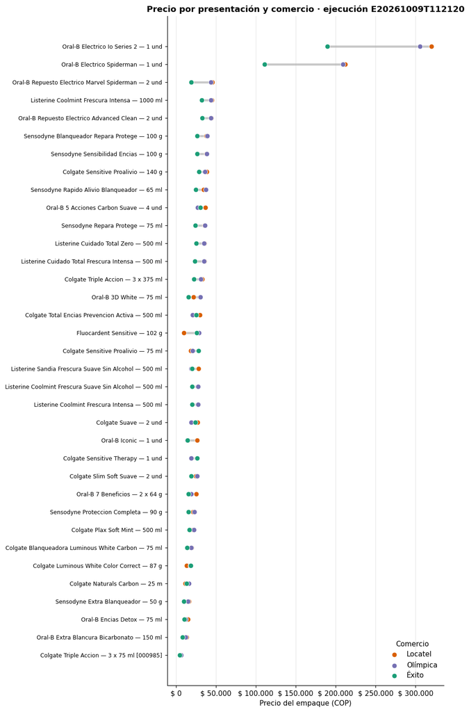

Figura 1: Precio del empaque (COP) de cada presentación comparable, por comercio (ejecución de referencia). La línea gris va del precio mínimo al máximo.

```python
precios = consulta(CTE_PRECIOS + " SELECT * FROM precios", ejec=EJEC)
orden = (precios.groupby("nombre_estandar").precio.max().sort_values().index.tolist())
if len(orden) > 35:   # para legibilidad: las 35 con mayor diferencia porcentual
    orden = [p for p in orden if p in set(q6.head(35).presentacion)]
y = {p: i for i, p in enumerate(orden)}
fig, ax = plt.subplots(figsize=(9, 0.36 * len(orden) + 1.6))
for p in orden:
    g = precios[precios.nombre_estandar == p]
    ax.hlines(y[p], g.precio.min(), g.precio.max(), color="#c8c8c8", lw=3, zorder=1)
for com, g in precios[precios.nombre_estandar.isin(orden)].groupby("comercio"):
    ax.scatter(g.precio, g.nombre_estandar.map(y), s=50, color=COLORES[com], label=com, zorder=3,
               edgecolor="white", linewidth=0.6)
ax.set_yticks(range(len(orden)), [textwrap.shorten(p, 58, placeholder="…") for p in orden], fontsize=8)
ax.xaxis.set_major_formatter(FMT_COP)
ax.set_xlabel("Precio del empaque (COP)")
ax.grid(axis="x", alpha=0.3)
ax.legend(title="Comercio", loc="lower right", frameon=False)
ax.set_title(f"Precio por presentación y comercio · ejecución {EJEC}")
plt.tight_layout(); plt.show()
```

Cada fila es una presentación idéntica (mismo `producto_id`) y cada punto el precio del empaque en un comercio. Cuanto más larga la línea gris, mayor la diferencia entre comercios. El eje está en pesos corrientes del día de captura; por eso se comparan precios dentro de una misma fila y no entre filas, que corresponden a productos y tamaños distintos.

## 6.2 Precio por unidad de contenido entre tamaños

**Ver código**

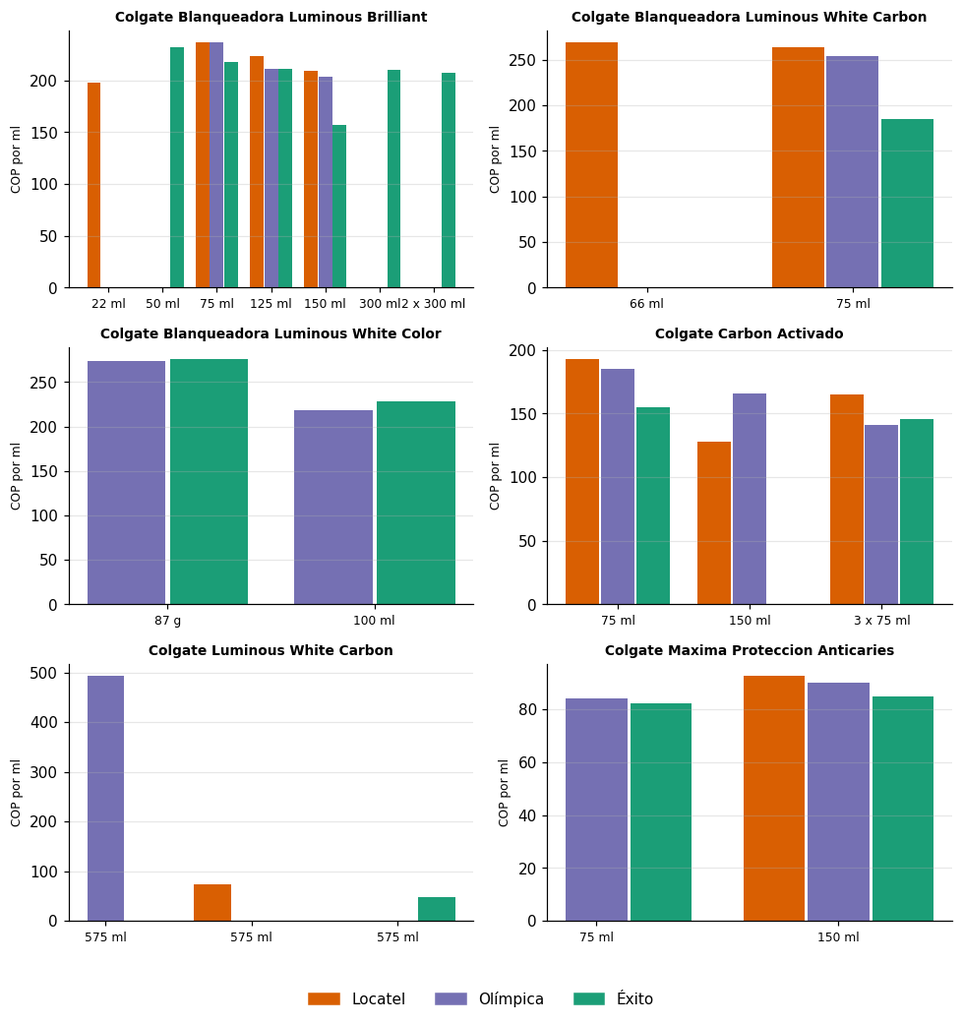

```python
if len(unidad_detalle):
    grupos = list(unidad_detalle.groupby(["producto", "unidad"]))[:6]
    n = len(grupos); cols = 2 if n > 1 else 1; filas = int(np.ceil(n / cols))
    fig, axes = plt.subplots(filas, cols, figsize=(9, 3.1 * filas), squeeze=False)
    for ax, ((prod, u), g) in zip(axes.flat, grupos):
        tam = sorted(g.contenido_total.unique())
        etiquetas = {t: g[g.contenido_total == t].presentacion.iloc[0].split(" — ")[-1] for t in tam}
        comercios_g = sorted(g.comercio.unique()); ancho = 0.8 / len(comercios_g)
        for j, com in enumerate(comercios_g):
            gg = g[g.comercio == com]
            xs = [tam.index(t) + (j - (len(comercios_g) - 1) / 2) * ancho for t in gg.contenido_total]
            ax.bar(xs, gg.cop_por_unidad, width=ancho * 0.95, color=COLORES[com], label=com)
        ax.set_xticks(range(len(tam)), [etiquetas[t] for t in tam], fontsize=8)
        ax.set_title(textwrap.shorten(prod, 45, placeholder="…"), fontsize=9)
        ax.set_ylabel(f"COP por {u}", fontsize=8)
        ax.grid(axis="y", alpha=0.3)
    for ax in list(axes.flat)[n:]:
        ax.axis("off")
    fig.legend([plt.Rectangle((0, 0), 1, 1, color=COLORES[c]) for c in sorted(COLORES) if c in set(unidad_detalle.comercio)],
               [c for c in sorted(COLORES) if c in set(unidad_detalle.comercio)], loc="lower center",
               ncol=4, frameon=False, bbox_to_anchor=(0.5, -0.02))
    plt.tight_layout(rect=(0, 0.04, 1, 1)); plt.show()
else:
    print("Sin productos con varios tamaños comparables.")
```

Cada panel corresponde a un mismo producto y formulación en distintos tamaños; las barras comparan el precio por unidad de contenido. Una barra más baja en un tamaño mayor indica que el empaque grande rinde más por peso pagado, aunque implique un desembolso total mayor. Se muestran hasta seis productos; la tabla de la consulta 5 contiene todos.

## 6.3 Oportunidades de ahorro

**Ver código**

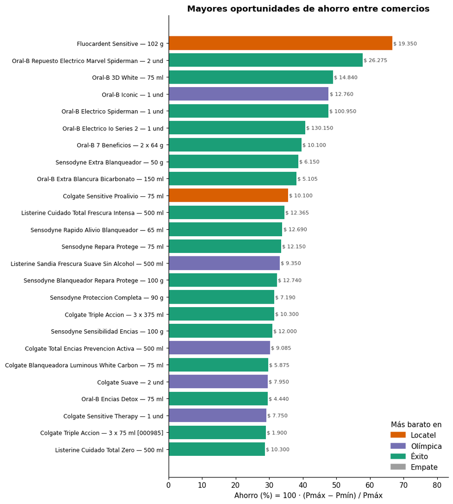

Figura 3: Ahorro porcentual al comprar cada presentación en el comercio más barato frente al más caro. El color indica el comercio más barato (gris: empate).

```python
a = q6.head(25).iloc[::-1]
colores = [COLORES.get(m, "#9e9e9e") if "=" not in m else "#9e9e9e" for m in a.mas_barato]
fig, ax = plt.subplots(figsize=(9, 0.34 * len(a) + 1.5))
ax.barh(range(len(a)), a.ahorro_pct, color=colores)
for i, (p, c) in enumerate(zip(a.ahorro_pct, a.ahorro_cop)):
    ax.text(p + 0.3, i, cop(c), va="center", fontsize=7.5, color="#444")
ax.set_yticks(range(len(a)), [textwrap.shorten(p, 58, placeholder="…") for p in a.presentacion], fontsize=8)
ax.set_xlabel("Ahorro (%) = 100 · (Pmáx − Pmín) / Pmáx")
ax.set_xlim(0, max(a.ahorro_pct.max() * 1.25, 1))
ax.legend([plt.Rectangle((0, 0), 1, 1, color=COLORES[c]) for c in sorted(COLORES) if c in set(precios.comercio)]
          + [plt.Rectangle((0, 0), 1, 1, color="#9e9e9e")],
          [c for c in sorted(COLORES) if c in set(precios.comercio)] + ["Empate"],
          title="Más barato en", loc="lower right", frameon=False)
ax.set_title("Mayores oportunidades de ahorro entre comercios")
plt.tight_layout(); plt.show()
```

**Ver código**

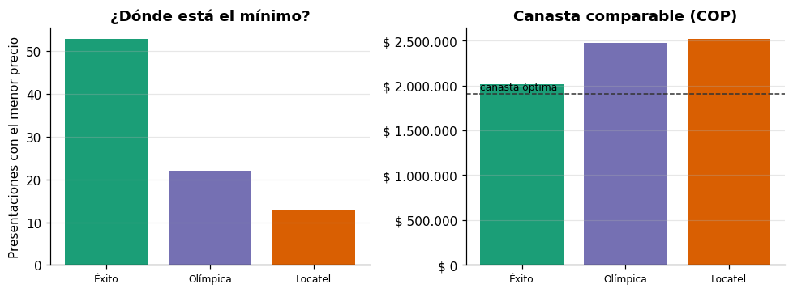

Figura 4: Izquierda: número de presentaciones en las que cada comercio tiene el menor precio (los empates cuentan para todos los empatados). Derecha: costo de la canasta de presentaciones comparables (una unidad de cada una).

```python
victorias = {c: 0 for c in canasta.comercio}
for m in q3.comercio_mas_barato:
    for c in m.split(" = "):
        victorias[c] = victorias.get(c, 0) + 1
fig, (a1, a2) = plt.subplots(1, 2, figsize=(9, 3.4))
a1.bar(list(victorias), list(victorias.values()), color=[COLORES[c] for c in victorias])
a1.set_ylabel("Presentaciones con el menor precio"); a1.set_title("¿Dónde está el mínimo?")
a2.bar(canasta.comercio, canasta.total, color=[COLORES[c] for c in canasta.comercio])
a2.axhline(optima, ls="--", color="#333", lw=1)
a2.annotate("canasta óptima", (-0.4, optima), xytext=(0, 3), textcoords="offset points", fontsize=8)
a2.yaxis.set_major_formatter(FMT_COP); a2.set_title("Canasta comparable (COP)")
for ax in (a1, a2):
    ax.tick_params(axis="x", labelsize=8); ax.grid(axis="y", alpha=0.3)
plt.tight_layout(); plt.show()
```

El gráfico de ahorro ordena las presentaciones por diferencia porcentual; la etiqueta indica el ahorro en pesos. Un porcentaje alto en un producto barato puede significar pocos pesos, por eso se reportan ambas medidas. La canasta compara comercios con las mismas 84 presentaciones y cantidades, de modo que la diferencia no se debe a surtidos distintos; la línea punteada es el costo de comprar cada presentación donde es más barata, que puede requerir varios pedidos (y varios costos de envío).

## 6.4 Oferta de la categoría por comercio

**Ver código**

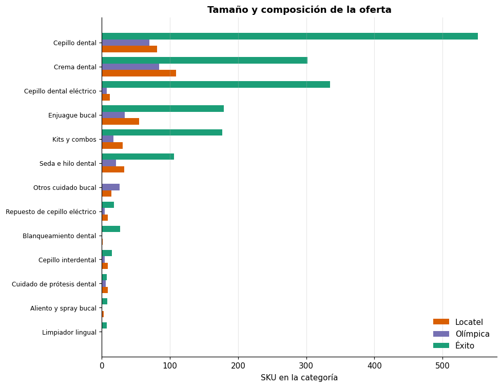

Figura 5: Número de SKU de cuidado bucal por subcategoría y comercio (ejecución de referencia).

```python
piv = oferta.pivot_table(index="subcategoria", columns="comercio", values="skus", fill_value=0)
piv = piv.loc[piv.sum(axis=1).sort_values().index]
fig, ax = plt.subplots(figsize=(9, 0.42 * len(piv) + 1.5))
alto = 0.8 / len(piv.columns)
for j, com in enumerate(piv.columns):
    ax.barh(np.arange(len(piv)) + (j - (len(piv.columns) - 1) / 2) * alto, piv[com], height=alto,
            color=COLORES[com], label=com)
ax.set_yticks(range(len(piv)), piv.index, fontsize=8)
ax.set_xlabel("SKU en la categoría"); ax.grid(axis="x", alpha=0.3)
ax.legend(frameon=False, loc="lower right"); ax.set_title("Tamaño y composición de la oferta")
plt.tight_layout(); plt.show()
```

## 6.5 Cambios de precio entre ejecuciones

Variación porcentual del precio de las presentaciones comparables entre la primera y la última ejecución, por comercio (solo si hay al menos dos ejecuciones con precios comparables).

**Ver código**

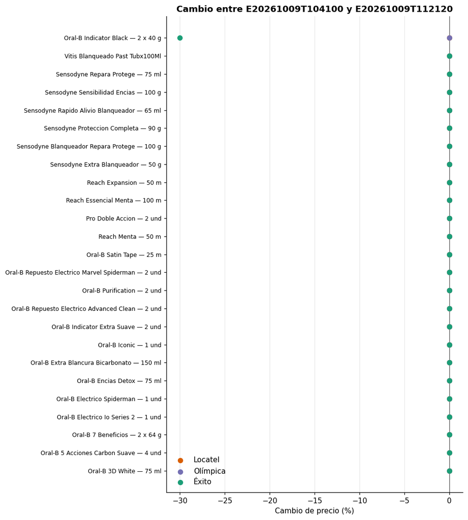

```
Pares presentación-comercio con cambio: 1 de 252; cambio mediano 0,0 %.
```

```python
cambios = consulta("""
WITH p AS (
    SELECT producto_id, nombre_estandar, comercio, ejecucion_id, MIN(precio) AS precio
    FROM v_observaciones WHERE comparable = 1 AND precio IS NOT NULL AND disponible = 1
    GROUP BY producto_id, comercio, ejecucion_id
), extremos AS (
    SELECT producto_id, comercio, MIN(ejecucion_id) AS primera, MAX(ejecucion_id) AS ultima
    FROM p GROUP BY producto_id, comercio HAVING COUNT(*) >= 2
)
SELECT a.nombre_estandar, a.comercio, e.primera, e.ultima, a.precio AS precio_inicial, b.precio AS precio_final,
       ROUND(100.0 * (b.precio - a.precio) / a.precio, 1) AS cambio_pct
FROM extremos e
JOIN p a ON a.producto_id = e.producto_id AND a.comercio = e.comercio AND a.ejecucion_id = e.primera
JOIN p b ON b.producto_id = e.producto_id AND b.comercio = e.comercio AND b.ejecucion_id = e.ultima
""")
if len(cambios):
    piv = cambios.pivot_table(index="nombre_estandar", columns="comercio", values="cambio_pct")
    piv = piv.loc[piv.abs().max(axis=1).sort_values().index].tail(25)
    fig, ax = plt.subplots(figsize=(9, 0.34 * len(piv) + 1.5))
    for com in piv.columns:
        ax.scatter(piv[com], range(len(piv)), color=COLORES[com], label=com, s=40, zorder=3)
    ax.axvline(0, color="#555", lw=0.8)
    ax.set_yticks(range(len(piv)), [textwrap.shorten(p, 58, placeholder="…") for p in piv.index], fontsize=8)
    ax.set_xlabel("Cambio de precio (%)"); ax.grid(axis="x", alpha=0.3)
    ax.legend(frameon=False); ax.set_title(f"Cambio entre {cambios.primera.min()} y {cambios.ultima.max()}")
    plt.tight_layout(); plt.show()
    print(f"Pares presentación-comercio con cambio: {(cambios.cambio_pct != 0).sum()} de {len(cambios)}; "
          f"cambio mediano {pct(cambios.cambio_pct.median())}.")
else:
    print("Solo hay una ejecución con precios comparables; se recomienda una segunda ejecución en otra fecha.")
```

# 7 Limitaciones y conclusiones

## 7.1 Conclusión para el consumidor

| presentacion | dónde comprar | precio | ahorro vs. más caro | ahorro % |
| --- | --- | --- | --- | --- |
| Colgate Blanqueadora Luminous Brilliant — 75 ml | Éxito | $ 16.350 | $ 1.400 | 7,9 % |
| Colgate Blanqueadora Luminous White Carbon — 75 ml | Éxito | $ 13.875 | $ 5.875 | 29,7 % |
| Colgate Blanqueadora Luminous White Glow — 70 g | Locatel | $ 23.775 | $ 8.025 | 25,2 % |
| Colgate Carbon Activado — 75 ml | Éxito | $ 11.600 | $ 2.850 | 19,7 % |
| Colgate Cep Harry Potter +6 | Olímpica | $ 24.990 | $ 1.660 | 6,2 % |
| Colgate Encias Therapy — 2 x 10 g | Locatel | $ 27.600 | $ 6.500 | 19,1 % |
| Colgate Kids Extra Suave — 2 und | Locatel | $ 25.950 | $ 4.550 | 14,9 % |
| Colgate Kids Minions — 45 ml | Olímpica | $ 8.290 | $ 1.420 | 14,6 % |
| Colgate Luminous White Brilliant — 125 ml | Olímpica = Éxito | $ 26.400 | $ 1.550 | 5,5 % |
| Colgate Luminous White Carbon — 575 ml | Éxito | $ 27.750 | $ 9.250 | 25,0 % |
| Colgate Luminous White Color Correct — 87 g | Locatel | $ 13.275 | $ 4.925 | 27,1 % |
| Colgate Max White — 131 ml | Olímpica = Éxito | $ 14.500 | $ 1.350 | 8,5 % |
| Colgate Maxima Proteccion Anticaries — 150 ml | Éxito | $ 12.750 | $ 1.150 | 8,3 % |
| Colgate Medio — 5 und | Éxito | $ 35.250 | $ 11.750 | 25,0 % |
| Colgate My First Sin Fluor — 40 ml | Locatel | $ 25.150 | $ 700 | 2,7 % |
| Colgate Naturals Carbon — 25 m | Locatel | $ 11.625 | $ 4.375 | 27,3 % |
| Colgate Ninos Smiles Extra Suave — 1 und | Olímpica | $ 20.200 | $ 4.500 | 18,2 % |
| Colgate Plax Kids Minions — 250 ml | Éxito | $ 15.750 | $ 450 | 2,8 % |
| Colgate Plax Odor Control — 500 ml | Éxito | $ 16.500 | $ 4.950 | 23,1 % |
| Colgate Plax Soft Mint — 500 ml | Éxito | $ 16.500 | $ 5.700 | 25,7 % |
| Colgate Procuidado Suave — 4 und | Éxito | $ 22.500 | $ 5.950 | 20,9 % |
| Colgate Sensitive Blanqueadora — 73 ml | Éxito | $ 18.400 | $ 3.850 | 17,3 % |
| Colgate Sensitive Pro Alivio — 60 g | Locatel | $ 11.850 | $ 3.050 | 20,5 % |
| Colgate Sensitive Proalivio — 140 g | Éxito | $ 28.500 | $ 9.900 | 25,8 % |
| Colgate Sensitive Proalivio — 75 ml | Locatel | $ 18.300 | $ 10.100 | 35,6 % |
| Colgate Sensitive Therapy — 1 und | Olímpica | $ 18.900 | $ 7.750 | 29,1 % |
| Colgate Slim Soft Suave — 2 und | Éxito | $ 19.125 | $ 7.425 | 28,0 % |
| Colgate Suave — 2 und | Olímpica | $ 18.900 | $ 7.950 | 29,6 % |
| Colgate Total Encias Prevencion Activa — 500 ml | Olímpica | $ 20.965 | $ 9.085 | 30,2 % |
| Colgate Total Original Mint — 150 ml | Olímpica | $ 23.400 | $ 3.550 | 13,2 % |
| Colgate Total — 575 ml | Éxito | $ 24.750 | $ 7.950 | 24,3 % |
| Colgate Triple Accion Blancura Medio — 2 x 50 g | Olímpica | $ 12.500 | $ 2.600 | 17,2 % |
| Colgate Triple Accion — 3 x 150 ml | Olímpica = Éxito | $ 13.450 | $ 600 | 4,3 % |
| Colgate Triple Accion — 3 x 375 ml | Éxito | $ 22.400 | $ 10.300 | 31,5 % |
| Colgate Triple Accion — 3 x 75 ml [000985] | Éxito | $ 4.650 | $ 1.900 | 29,0 % |
| Colgate Triple Accion — 3 x 75 ml [351034] | Olímpica | $ 19.600 | $ 650 | 3,2 % |
| Colgate Twister Medio — 2 und | Olímpica | $ 13.500 | $ 1.450 | 9,7 % |
| Colgate Whitening — 75 ml | Éxito | $ 14.050 | $ 700 | 4,7 % |
| Colgate — 75 ml [702599] | Locatel | $ 13.750 | $ 2.050 | 13,0 % |
| Corega Tabs Unds Tabletas | Éxito | $ 27.360 | $ 5.240 | 16,1 % |
| Fluocardent Kids Fresa | Locatel = Olímpica | $ 9.050 | $ 690 | 7,1 % |
| Fluocardent Limpieza Max — 2 und [030888] | Locatel | $ 12.050 | $ 700 | 5,5 % |
| Fluocardent Sensitive — 102 g | Locatel | $ 9.640 | $ 19.350 | 66,7 % |
| GUM Baby Paw Patrol — 50 ml | Olímpica | $ 19.920 | $ 5.280 | 21,0 % |
| GUM Barbie — 75 m | Éxito | $ 11.000 | $ 3.450 | 23,9 % |
| Listerine Control Calculo Zero — 500 ml | Éxito | $ 31.650 | $ 4.200 | 11,7 % |
| Listerine Control Calculo — 500 ml | Éxito | $ 30.080 | $ 5.770 | 16,1 % |
| Listerine Coolmint Frescura Intensa — 1000 ml | Éxito | $ 32.200 | $ 12.750 | 28,4 % |
| Listerine Coolmint Frescura Intensa — 180 ml | Éxito | $ 10.640 | $ 2.160 | 16,9 % |
| Listerine Coolmint Frescura Intensa — 500 ml | Éxito | $ 19.950 | $ 7.650 | 27,7 % |
| Listerine Coolmint Frescura Suave Sin Alcohol — 180 ml | Olímpica | $ 12.750 | $ 50 | 0,4 % |
| Listerine Coolmint Frescura Suave Sin Alcohol — 500 ml | Éxito | $ 19.950 | $ 7.650 | 27,7 % |
| Listerine Cuidado Total Frescura Intensa — 500 ml | Éxito | $ 23.485 | $ 12.365 | 34,5 % |
| Listerine Cuidado Total Zero — 500 ml | Éxito | $ 25.550 | $ 10.300 | 28,7 % |
| Listerine Kids Bubble — 500 ml | Olímpica | $ 25.990 | $ 1.060 | 3,9 % |
| Listerine Original Frescura Intensa — 500 ml | Éxito | $ 29.520 | $ 6.330 | 17,7 % |
| Listerine Profesional Encias — 250 ml | Olímpica | $ 37.790 | $ 4.410 | 10,5 % |
| Listerine Sandia Frescura Suave Sin Alcohol — 500 ml | Olímpica | $ 18.900 | $ 9.350 | 33,1 % |
| Listerine Whitening Extreme Frescura Suave — 473 ml | Éxito | $ 21.975 | $ 6.475 | 22,8 % |
| Oral-B 3D White — 75 ml | Éxito | $ 15.450 | $ 14.840 | 49,0 % |

*Se muestran 60 de 84 filas.*

- **Dónde comprar cada producto.** La tabla anterior indica, para cada presentación, el comercio con el menor precio observado el día de captura y el ahorro frente al más caro. Ningún comercio es el más barato en todo: Éxito lidera en 53, Olímpica lidera en 22, Locatel lidera en 13 presentaciones.
- **Si se compra todo en un solo lugar**, la canasta comparable es más económica en **Éxito** ($ 2.010.100); repartir la compra entre comercios bajaría el total a $ 1.907.115, pero puede implicar varios envíos o desplazamientos.
- **Ahorro unitario vs. desembolso total.** Entre tamaños del mismo producto, el menor precio por unidad se encontró en Colgate Blanqueadora Luminous Brilliant — 150 ml en Éxito (157,50 COP/ml); Colgate Blanqueadora Luminous White Carbon — 75 ml en Éxito (185,00 COP/ml); Colgate Blanqueadora Luminous White Color — 100 ml en Olímpica (218,50 COP/ml). Un empaque más grande o un paquete múltiple puede costar menos por mL, g o unidad y, aun así, exigir un pago mayor; conviene solo si el producto se va a usar antes de su vencimiento.
- **Condiciones de compra.** Los precios corresponden al vendedor principal de cada sitio, sin costos de envío, y 61 de las observaciones comparables de la ejecución de referencia estaban en promoción; los descuentos condicionados (por ejemplo «lleve 2», precio con tarjeta de la marca) no se reflejan en el precio extraído.

## 7.2 Limitaciones

- **Momento de captura.** Los precios representan el momento y las condiciones de cada ejecución; no son permanentes. Las promociones cambian a diario y algunos precios pueden depender de la ciudad o del canal de venta configurado por defecto en el sitio.
- **Cobertura de la API.** El total de referencia es el que reporta la API del sitio; la página web puede mostrar un número ligeramente distinto si oculta productos agotados o de vendedores externos.
- **Correspondencia.** El EAN es muy confiable, pero algunos comercios usan códigos internos o el EAN unitario en paquetes; esos casos se separan por número de unidades o se resuelven con la clave normalizada y el archivo de correspondencias manuales.
- **Contenido.** Se extrae del nombre o de la ficha técnica con reglas; nombres incompletos impiden calcular el precio por unidad (consulta 7). Los precios por mL, g, m y unidad no se mezclan.
- **No es una recomendación de sustitución.** Productos con principio activo (por ejemplo, enjuagues con clorhexidina o cremas para sensibilidad) se comparan solo dentro de la misma formulación y concentración; un menor precio no implica que un producto reemplace a otro.

## 7.3 Verificación del modo sin conexión

```python
if VERIFICAR_SIN_CONEXION:
    with tempfile.TemporaryDirectory() as tmp:
        prueba_db = Path(tmp) / "reproceso.sqlite"
        scraper.reprocesar_sin_conexion(prueba_db, scraper.RAW_DIR, verbose=False)
        off = sqlite3.connect(prueba_db)
        sql_v = ("SELECT ejecucion_id, comercio_id, sku_comercio, fecha_hora_consulta, precio, precio_lista, "
                 "es_promocion, disponible FROM observaciones ORDER BY 1, 2, 3")
        original, reproceso = pd.read_sql(sql_v, con), pd.read_sql(sql_v, off)
        resumen_v = pd.DataFrame({
            "tabla": ["observaciones", "anuncios", "productos comparables"],
            "base entregada": [len(original), con.execute("SELECT COUNT(*) FROM anuncios").fetchone()[0],
                               N_COMPARABLES],
            "reproceso desde raw/": [len(reproceso), off.execute("SELECT COUNT(*) FROM anuncios").fetchone()[0],
                                     off.execute("SELECT COUNT(*) FROM productos WHERE comparable=1").fetchone()[0]],
        })
        identicas = original.equals(reproceso)
        off.close()
    display(tabla(resumen_v))
    print(f"Observaciones idénticas (precio, fecha y hora, promoción, disponibilidad): {identicas}")
```

| tabla | base entregada | reproceso desde raw/ |
| --- | --- | --- |
| observaciones | 9532 | 9532 |
| anuncios | 2383 | 2383 |
| productos comparables | 84 | 84 |

```
Observaciones idénticas (precio, fecha y hora, promoción, disponibilidad): True
```

El modo sin conexión vuelve a procesar las respuestas guardadas en `raw/` sin consultar ningún sitio (`python scraper.py --sin-conexion`). Si un sitio cambia su estructura o bloquea el acceso después de la entrega, la extracción se verifica a partir de esas copias.

# 8 Anexo: entorno de ejecución

|  | componente | versión |
| --- | --- | --- |
| 0 | Python | 3.13.14 |
| 1 | pandas | 3.0.2 |
| 2 | numpy | 2.4.4 |
| 3 | matplotlib | 3.10.8 |
| 4 | requests | 2.33.1 |
| 5 | SQLite | 3.50.4 |
| 6 | Sistema | Windows-10-10.0.19045-SP0 |